# **Machine Learning: Personal Loan Campaign**

### **Description**

### **Context**

AllLife Bank is a mid-sized, fast-growing US-based financial institution that offers a range of retail banking services, including savings and checking accounts, fixed deposits, and personal loans. The bank’s business model is centered on building long-term customer relationships, expanding its retail footprint, and growing its loan portfolio to drive sustainable profitability through interest income.

It currently relies on a large base of liability customers (depositors) but faces a significant under-representation of asset customers (borrowers). To drive profitability through interest income, the bank must aggressively expand its loan portfolio by converting existing depositors into personal loan customers.

Last year’s pilot campaign achieved a 9% conversion rate, validating the potential of this strategy. However, to optimize marketing spend and improve efficiency, the retail marketing department requires a more data-driven approach. Enhancing the success ratio of these campaigns is critical for sustainable growth and maximizing customer lifetime value.

### **Objective**

The objective is to develop a predictive classification model that identifies patterns and key factors driving personal loan adoption among existing liability customers. By uncovering the demographic and behavioral drivers of loan conversion, the goal is to enable targeted segmentation and more precise marketing interventions that improve campaign conversion rates, optimize marketing spend, and enhance overall profitability through higher-quality loan portfolio growth.

### **Data Dictionary**

- ID: Customer ID
- Age: Customer’s age in completed years
- Experience: # years of professional experience
- Income: Annual income of the customer (in thousand dollars)
- ZIP Code: Home Address ZIP code.
- Family: The family size of the customer
- CCAvg: Average spending on credit cards per month (in thousand dollars)
- Education: Education Level. 1: Undergrad; 2: Graduate;3: Advanced/Professional
- Mortgage: Value of house mortgage if any. (in thousand dollars)
- Personal_Loan: Did this customer accept the personal loan offered in the last campaign?
- Securities_Account: Does the customer have a securities account with the bank?
- CD_Account: Does the customer have a certificate of deposit (CD) account with the bank?
- Online: Do customers use Internet banking facilities?
- CreditCard: Does the customer use a credit card issued by any other Bank (excluding All Life Bank)?

### **Domain Details**

- **Retail Banking Services** - The suite of offerings provided by AllLife Bank to its individual customers, including accounts and loans
- **Personal Loan** - A personal loan is an unsecured loan provided by financial institutions that does not require any form of collateral
- **Fixed Deposit** - A financial product offered by the bank that represents long-term savings held for a specific period
- **Depositers** - Customers who hold financial assets within the bank, such as savings, checking accounts, or fixed deposits.
- **Borrowers** - Customers who have taken out personal loans from the bank.
- **Asset Customers** - A term used to describe borrowers, representing the segment the bank is currently seeking to grow to improve its loan portfolio.
- **Liability Customers** - Existing customers (depositors) who hold accounts with the bank, representing the bank's current, large customer base.
- **Loan Business** - The bank's operational focus on expanding its loan portfolio to generate revenue.
- **Loan Interest** - The revenue generated by the bank from the interest income on its loan portfolio.
- **Interest Rate** - The percentage rate charged by the bank on personal loans, which contributes to the bank's sustainable profitability.
- **Securities Account** - An account held at a financial institution that allows the holder to hold financial assets like stocks or bonds.
- **Certificate of deposit** - A financial product similar to a fixed deposit, where a sum of money is held for a fixed term with an interest rate

### **Importing Necessary Libraries**

```python
# Libraries to help reading and manipulating the data
import pandas as pd
import numpy as np

# Libraries to help for data visualization
import matplotlib.pyplot as plt
import seaborn as sns

# Libraries to split data, and build decision trees
from sklearn.model_selection import train_test_split
from sklearn.preprocessing import StandardScaler
from sklearn.tree import DecisionTreeClassifier
from sklearn import tree

# Libraries to perform statistical analysis
import scipy.stats as stats

# Libraries to perform different metric scores
from sklearn.metrics import (
    f1_score,
    precision_score,
    recall_score,
    accuracy_score,
    classification_report,
    confusion_matrix,
    ConfusionMatrixDisplay,
    make_scorer
)

# Library to suppress warnings or deprecation notes
import warnings
warnings.filterwarnings("ignore")
```

### **Importing Dataset**

```python
# uncomment and run the following lines for Google Colab
from google.colab import drive
drive.mount('/content/drive')
customer_data = pd.read_csv('/content/drive/MyDrive/AI_Shared_Content/M2_W4_Project/Loan_Modelling.csv')

# Data Copy (to avoid changes in the orginal data)
data = customer_data.copy()
```

### **Data Check and Overview**

### **Check the first and last 5 records of the dataset**

```python
# To get the first 5 records
data.head()
```

|  | ID | Age | Experience | Income | ZIPCode | Family | CCAvg | Education | Mortgage | Personal_Loan | Securities_Account | CD_Account | Online | CreditCard |
| --- | --- | --- | --- | --- | --- | --- | --- | --- | --- | --- | --- | --- | --- | --- |
| 0 | 1 | 25 | 1 | 49 | 91107 | 4 | 1.6 | 1 | 0 | 0 | 1 | 0 | 0 | 0 |
| 1 | 2 | 45 | 19 | 34 | 90089 | 3 | 1.5 | 1 | 0 | 0 | 1 | 0 | 0 | 0 |
| 2 | 3 | 39 | 15 | 11 | 94720 | 1 | 1.0 | 1 | 0 | 0 | 0 | 0 | 0 | 0 |
| 3 | 4 | 35 | 9 | 100 | 94112 | 1 | 2.7 | 2 | 0 | 0 | 0 | 0 | 0 | 0 |
| 4 | 5 | 35 | 8 | 45 | 91330 | 4 | 1.0 | 2 | 0 | 0 | 0 | 0 | 0 | 1 |

```python
# To get the last 5 records
data.tail()
```

|  | ID | Age | Experience | Income | ZIPCode | Family | CCAvg | Education | Mortgage | Personal_Loan | Securities_Account | CD_Account | Online | CreditCard |
| --- | --- | --- | --- | --- | --- | --- | --- | --- | --- | --- | --- | --- | --- | --- |
| 4995 | 4996 | 29 | 3 | 40 | 92697 | 1 | 1.9 | 3 | 0 | 0 | 0 | 0 | 1 | 0 |
| 4996 | 4997 | 30 | 4 | 15 | 92037 | 4 | 0.4 | 1 | 85 | 0 | 0 | 0 | 1 | 0 |
| 4997 | 4998 | 63 | 39 | 24 | 93023 | 2 | 0.3 | 3 | 0 | 0 | 0 | 0 | 0 | 0 |
| 4998 | 4999 | 65 | 40 | 49 | 90034 | 3 | 0.5 | 2 | 0 | 0 | 0 | 0 | 1 | 0 |
| 4999 | 5000 | 28 | 4 | 83 | 92612 | 3 | 0.8 | 1 | 0 | 0 | 0 | 0 | 1 | 1 |

### **Check the shape of the dataset**

```python
# Get the shape of dataset
data.shape
```

```
(5000, 14)
```

There are 5000 rows and 14 columns in the given dataset

### **Exploratory Data Analysis**

### **Check the data types of all columns in the dataset**

```python
# Get info of the dataset
data.info()
```

```
<class 'pandas.core.frame.DataFrame'>
RangeIndex: 5000 entries, 0 to 4999
Data columns (total 14 columns):
 #   Column              Non-Null Count  Dtype
---  ------              --------------  -----
 0   ID                  5000 non-null   int64
 1   Age                 5000 non-null   int64
 2   Experience          5000 non-null   int64
 3   Income              5000 non-null   int64
 4   ZIPCode             5000 non-null   int64
 5   Family              5000 non-null   int64
 6   CCAvg               5000 non-null   float64
 7   Education           5000 non-null   int64
 8   Mortgage            5000 non-null   int64
 9   Personal_Loan       5000 non-null   int64
 10  Securities_Account  5000 non-null   int64
 11  CD_Account          5000 non-null   int64
 12  Online              5000 non-null   int64
 13  CreditCard          5000 non-null   int64
dtypes: float64(1), int64(13)
memory usage: 547.0 KB
```

### **Observation**

- There are 14 columns in the given dataset
- All columns are numeric(int) except CCAvg column which is float
- All columns are having full 5000 non-null values
- Overall 547.0KB memory of data is available which is not too large
- ZIPCode is categorical value rather than numerical
- Categorical data like Education is already encoded and stored as numerical value
- Personal_Loan is the dependent variable
- Binary categorical columns (Personal_Loan, Securities_Account, CD_Account, Online and CreditCard) are already encoded and stored as numerical values

### **Check the duplicate and missing values in the dataset**

```python
# Get the duplicated values
data.duplicated().sum()
```

```
np.int64(0)
```

### **Observation**

- No duplicate values in the given *data*

### **Check and drop the columns with all unique values**

```python
# Check and drop the unique column (ID)
data["ID"].nunique()
```

```
5000
```

```python
# All values are unique in ID Column, so we can drop it
data.drop("ID", axis=1, inplace=True)
```

```python
# Get info of the dataset after ID column drop
data.info()
```

```
<class 'pandas.core.frame.DataFrame'>
RangeIndex: 5000 entries, 0 to 4999
Data columns (total 13 columns):
 #   Column              Non-Null Count  Dtype
---  ------              --------------  -----
 0   Age                 5000 non-null   int64
 1   Experience          5000 non-null   int64
 2   Income              5000 non-null   int64
 3   ZIPCode             5000 non-null   int64
 4   Family              5000 non-null   int64
 5   CCAvg               5000 non-null   float64
 6   Education           5000 non-null   int64
 7   Mortgage            5000 non-null   int64
 8   Personal_Loan       5000 non-null   int64
 9   Securities_Account  5000 non-null   int64
 10  CD_Account          5000 non-null   int64
 11  Online              5000 non-null   int64
 12  CreditCard          5000 non-null   int64
dtypes: float64(1), int64(12)
memory usage: 507.9 KB
```

```python
# Check the data after ID column drop
data.head()
```

|  | Age | Experience | Income | ZIPCode | Family | CCAvg | Education | Mortgage | Personal_Loan | Securities_Account | CD_Account | Online | CreditCard |
| --- | --- | --- | --- | --- | --- | --- | --- | --- | --- | --- | --- | --- | --- |
| 0 | 25 | 1 | 49 | 91107 | 4 | 1.6 | 1 | 0 | 0 | 1 | 0 | 0 | 0 |
| 1 | 45 | 19 | 34 | 90089 | 3 | 1.5 | 1 | 0 | 0 | 1 | 0 | 0 | 0 |
| 2 | 39 | 15 | 11 | 94720 | 1 | 1.0 | 1 | 0 | 0 | 0 | 0 | 0 | 0 |
| 3 | 35 | 9 | 100 | 94112 | 1 | 2.7 | 2 | 0 | 0 | 0 | 0 | 0 | 0 |
| 4 | 35 | 8 | 45 | 91330 | 4 | 1.0 | 2 | 0 | 0 | 0 | 0 | 0 | 1 |

### **Observation**

- We checked the ID column uniqueness, we dropped it since it has unique values.

### **Check the statistical summary of the dataset**

```python
# Get the statistical summary of the dataset
data.describe(include="all").T
```

|  | count | mean | std | min | 25% | 50% | 75% | max |
| --- | --- | --- | --- | --- | --- | --- | --- | --- |
| Age | 5000.0 | 45.338400 | 11.463166 | 23.0 | 35.0 | 45.0 | 55.0 | 67.0 |
| Experience | 5000.0 | 20.104600 | 11.467954 | -3.0 | 10.0 | 20.0 | 30.0 | 43.0 |
| Income | 5000.0 | 73.774200 | 46.033729 | 8.0 | 39.0 | 64.0 | 98.0 | 224.0 |
| ZIPCode | 5000.0 | 93169.257000 | 1759.455086 | 90005.0 | 91911.0 | 93437.0 | 94608.0 | 96651.0 |
| Family | 5000.0 | 2.396400 | 1.147663 | 1.0 | 1.0 | 2.0 | 3.0 | 4.0 |
| CCAvg | 5000.0 | 1.937938 | 1.747659 | 0.0 | 0.7 | 1.5 | 2.5 | 10.0 |
| Education | 5000.0 | 1.881000 | 0.839869 | 1.0 | 1.0 | 2.0 | 3.0 | 3.0 |
| Mortgage | 5000.0 | 56.498800 | 101.713802 | 0.0 | 0.0 | 0.0 | 101.0 | 635.0 |
| Personal_Loan | 5000.0 | 0.096000 | 0.294621 | 0.0 | 0.0 | 0.0 | 0.0 | 1.0 |
| Securities_Account | 5000.0 | 0.104400 | 0.305809 | 0.0 | 0.0 | 0.0 | 0.0 | 1.0 |
| CD_Account | 5000.0 | 0.060400 | 0.238250 | 0.0 | 0.0 | 0.0 | 0.0 | 1.0 |
| Online | 5000.0 | 0.596800 | 0.490589 | 0.0 | 0.0 | 1.0 | 1.0 | 1.0 |
| CreditCard | 5000.0 | 0.294000 | 0.455637 | 0.0 | 0.0 | 0.0 | 1.0 | 1.0 |

### **Observation**

- The mean age of customers is 45.33 years, ranging from 23 to 67.
- The mean experience is 20.1 years, which having minimum as -3 (Need to check data) and maximum as 43 years.
- Minimum Experience is -3, which is not realistic. we has to either clean or impute it.
- The mean income is 73.77K which is way higher than the standard deviation (46K). This indicated high variable in the income levels.
- The minimum income is 8K and maximum income is 224K which clearly indicating there is wide range across income of customers.
- 59.68% of customers are available in online, whereas remaining 40.32% customers are offline.
- Family size ranges between 1 to 4 members and its mean is 2.39.
- Maximum mortgage value of 635000 dollar compared to median 0 dollar , which reflects high skewed distribution of mortgage.
- ZIPCode appears numeric but its actually categorical. The mean ZIPCode doesn't have much meaning in the statistical sense.

### **Data Pre-Processing and Cleanup**

### **Check and Clean the negative values in 'Experience' column**

```python
# Get the negative experience customers
data[data["Experience"] < 0].describe(include="all").T
```

|  | count | mean | std | min | 25% | 50% | 75% | max |
| --- | --- | --- | --- | --- | --- | --- | --- | --- |
| Age | 52.0 | 24.519231 | 1.475159 | 23.0 | 24.00 | 24.0 | 25.000 | 29.0 |
| Experience | 52.0 | -1.442308 | 0.639039 | -3.0 | -2.00 | -1.0 | -1.000 | -1.0 |
| Income | 52.0 | 69.942308 | 37.955295 | 12.0 | 40.75 | 65.5 | 86.750 | 150.0 |
| ZIPCode | 52.0 | 93240.961538 | 1611.654806 | 90065.0 | 92167.75 | 93060.0 | 94720.000 | 95842.0 |
| Family | 52.0 | 2.865385 | 0.970725 | 1.0 | 2.00 | 3.0 | 4.000 | 4.0 |
| CCAvg | 52.0 | 2.129423 | 1.750562 | 0.2 | 1.00 | 1.8 | 2.325 | 7.2 |
| Education | 52.0 | 2.076923 | 0.836570 | 1.0 | 1.00 | 2.0 | 3.000 | 3.0 |
| Mortgage | 52.0 | 43.596154 | 90.027068 | 0.0 | 0.00 | 0.0 | 0.000 | 314.0 |
| Personal_Loan | 52.0 | 0.000000 | 0.000000 | 0.0 | 0.00 | 0.0 | 0.000 | 0.0 |
| Securities_Account | 52.0 | 0.115385 | 0.322603 | 0.0 | 0.00 | 0.0 | 0.000 | 1.0 |
| CD_Account | 52.0 | 0.000000 | 0.000000 | 0.0 | 0.00 | 0.0 | 0.000 | 0.0 |
| Online | 52.0 | 0.576923 | 0.498867 | 0.0 | 0.00 | 1.0 | 1.000 | 1.0 |
| CreditCard | 52.0 | 0.288462 | 0.457467 | 0.0 | 0.00 | 0.0 | 1.000 | 1.0 |

```python
# Checking all the negative values present in the Experience column
data[data['Experience'] < 0]['Experience'].value_counts()
```

| Experience | count |
| --- | --- |
| -1 | 33 |
| -2 | 15 |
| -3 | 4 |

**dtype:** int64

### **Observation**

- There are 52 customers are having negative experience range between -3 to -1
- There are 33 customers having -1 experience value, 15 customers having -2 experience value, 4 customers having -3 experience value
- Average age of affected experience is 24.51 years
- As young customers are crucial for positioning loan products, dropping negative values record doesn't make sense.
- All the negative experience records have not taken any personal loan

We will also analyse the records with no experience (0)

```python
# Get the customers with no experience
data[data["Experience"] == 0].describe(include="all").T
```

|  | count | mean | std | min | 25% | 50% | 75% | max |
| --- | --- | --- | --- | --- | --- | --- | --- | --- |
| Age | 66.0 | 25.636364 | 1.145377 | 24.0 | 25.00 | 26.00 | 26.00 | 30.0 |
| Experience | 66.0 | 0.000000 | 0.000000 | 0.0 | 0.00 | 0.00 | 0.00 | 0.0 |
| Income | 66.0 | 69.651515 | 46.261961 | 12.0 | 38.00 | 53.50 | 90.25 | 195.0 |
| ZIPCode | 66.0 | 93251.136364 | 1822.507308 | 90028.0 | 92044.25 | 93558.00 | 94588.50 | 96094.0 |
| Family | 66.0 | 2.787879 | 1.102656 | 1.0 | 2.00 | 3.00 | 4.00 | 4.0 |
| CCAvg | 66.0 | 1.973939 | 1.946700 | 0.1 | 0.90 | 1.55 | 2.00 | 7.2 |
| Education | 66.0 | 2.181818 | 0.821052 | 1.0 | 1.25 | 2.00 | 3.00 | 3.0 |
| Mortgage | 66.0 | 41.106061 | 86.726294 | 0.0 | 0.00 | 0.00 | 0.00 | 323.0 |
| Personal_Loan | 66.0 | 0.106061 | 0.310275 | 0.0 | 0.00 | 0.00 | 0.00 | 1.0 |
| Securities_Account | 66.0 | 0.121212 | 0.328875 | 0.0 | 0.00 | 0.00 | 0.00 | 1.0 |
| CD_Account | 66.0 | 0.030303 | 0.172733 | 0.0 | 0.00 | 0.00 | 0.00 | 1.0 |
| Online | 66.0 | 0.469697 | 0.502905 | 0.0 | 0.00 | 0.00 | 1.00 | 1.0 |
| CreditCard | 66.0 | 0.227273 | 0.422282 | 0.0 | 0.00 | 0.00 | 0.00 | 1.0 |

### **Observation**

```python
# Set all the customer records with negative experience to zero experience
data.loc[data["Experience"] < 0, "Experience"] = data['Age'] - 25
data['Experience'] = data['Experience'].clip(lower=0)

# Verify the customer count with experience less than zero
data[data["Experience"] < 0].count()
```

|  | 0 |
| --- | --- |
| Age | 0 |
| Experience | 0 |
| Income | 0 |
| ZIPCode | 0 |
| Family | 0 |
| CCAvg | 0 |
| Education | 0 |
| Mortgage | 0 |
| Personal_Loan | 0 |
| Securities_Account | 0 |
| CD_Account | 0 |
| Online | 0 |
| CreditCard | 0 |

**dtype:** int64

### **Univariate Analysis**

### **Numerical (continuous) variables and histogram**

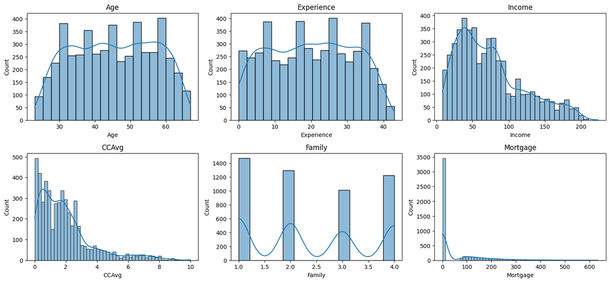

```python
# Numerical (continuous) variables and histogram
# Plot figure size
plt.figure(figsize=(15, 10))

# Create the list of continuous numerical features for plot histogram to check the distribution and skewness of dataset
num_features = ['Age', 'Experience', 'Income', 'CCAvg', 'Family', 'Mortgage']

# Create the histplot for each numerical feature
for i, feature in enumerate(num_features):
    plt.subplot(3, 3, i+1)
    sns.histplot(data[feature], kde=True)
    plt.title(feature)
    plt.tight_layout()
```

### **Numerical (continuous) variables and box plots**

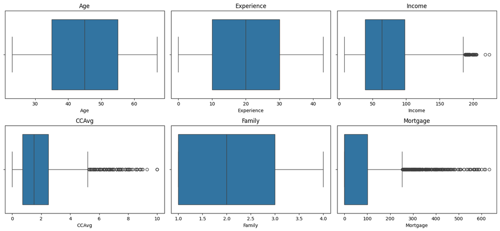

```python
# Numerical (continuous) variables and box plots
# Plot figure size
plt.figure(figsize=(15, 10))

# Create the list of continuous numerical features for plot boxplot
features = ['Age', 'Experience', 'Income', 'CCAvg', 'Family', 'Mortgage']

# Create the boxplot for each numerical feature
for i, col in enumerate(features):
    plt.subplot(3, 3, i+1)
    sns.boxplot(data=data, x=col)
    plt.title(col)
    plt.tight_layout()
```

### **Category variables and count plots**

```python
# Category variables and count plots
# define the list of categorical features to analyse with count plots
category_features = ['Securities_Account', 'CD_Account', 'Online', 'CreditCard', 'Personal_Loan', 'Education', 'Family']
```

```
Securities_Account: 0: 89.56% | 1: 10.44%


CD_Account: 0: 93.96% | 1: 6.04%


Online: 1: 59.68% | 0: 40.32%


CreditCard: 0: 70.60% | 1: 29.40%


Personal_Loan: 0: 90.40% | 1: 9.60%


Education: 1: 41.92% | 3: 30.02% | 2: 28.06%


Family: 1: 29.44% | 2: 25.92% | 4: 24.44% | 3: 20.20%
```

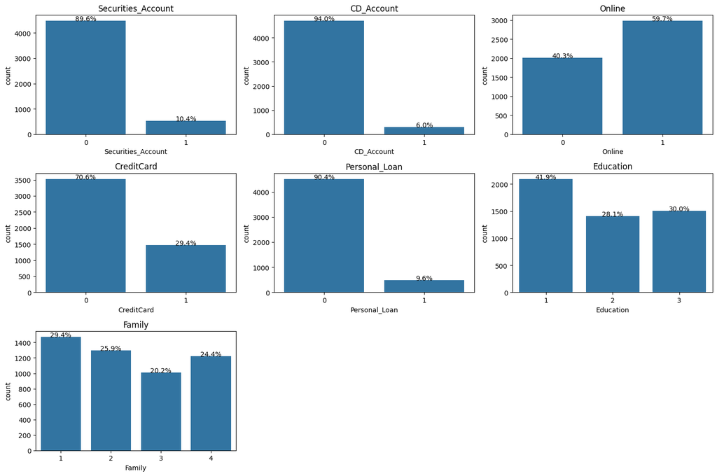

```python
for feature in category_features:
  # Calculate the percentage of each unique value in the feature
  percentages = data[feature].value_counts(normalize=True) * 100
  print (f"{feature}: ", end='')
  print (' | '.join([f"{idx}: {val:.2f}%" for idx, val in percentages.
items()])) # Using .2f for two decimal places
  print('\n')

# Set the figure size for the count plots
plt.figure(figsize=(15, 10))

# Create the countplot for each categorical feature
for i, feature in enumerate(category_features):
    plt.subplot(3, 3, i + 1)
    ax = sns.countplot(data=data, x=feature)
    # Get the total number of data points for percentage calculation
    total = len(data)

    # Add percentage labels on top of each bar
    for p in ax.patches:
        # Calculate the percentage for the current bar
        percentage = '{:.1f}%'.format(100 * p.get_height()/total)
        x = p.get_x() + p.get_width() / 2
        y = p.get_height()
        plt.annotate(percentage, (x, y), ha='center')
    plt.title(feature)
    plt.tight_layout()
```

### **Observations**

- **Securities_Account**: A vast majority of customers (89.56%) do not have a securities account with the bank, while only a small percentage (10.44%) do.
- **CD_Account**: Similar to securities accounts, most customers (93.96%) do not have a Certificate of Deposit (CD) account, with a mere 6.04% having one.
- **Online**: A larger proportion of customers (59.68%) use internet banking facilities, compared to those who don't (40.32%).
- **CreditCard**: The majority of customers (70.60%) do not use a credit card issued by other banks, whereas 29.40% do.
- **Personal_Loan**: This is the target variable. A significant imbalance is observed, with only 9.60% of customers having accepted the personal loan offer, while 90.40% have not. This indicates a rare event, which is common in classification problems and might require special handling during model training.
- **Education**: The education levels are fairly distributed, with Undergrad (1) being the most common at 41.92%, followed by Advanced/Professional (3) at 30.02%, and Graduate (2) at 28.06%.
- **Family**: Customers with a family size of 1 are the most frequent (29.44%), followed closely by family size 2 (25.92%) and 4 (24.44%). Family size 3 is the least common among these categories at 20.20%.

### **Zipcode analysis**

Based on the ZIPCode analysis (statistics). The data looks uneven and also too sparse. we will check the unique counts and do the encoding to make it more efficient and less sparse.

```python
# Get the distinct zipcodes
data['ZIPCode'].value_counts().count()
```

```
np.int64(467)
```

```python
# Create a new column ZIPShort with first 3 digits from ZIPCode
data['ZIPShort'] = data['ZIPCode'].astype(str).str[:3]
data['ZIPShort'].value_counts().count()
```

```
np.int64(57)
```

- We confirmed that the new ZIPShort having only unique values of 57 compared to previous 467 ZIPCode.

### **Bivariate Analysis**

### **Numerical(continuous) variables and Heatmap correlation plot**

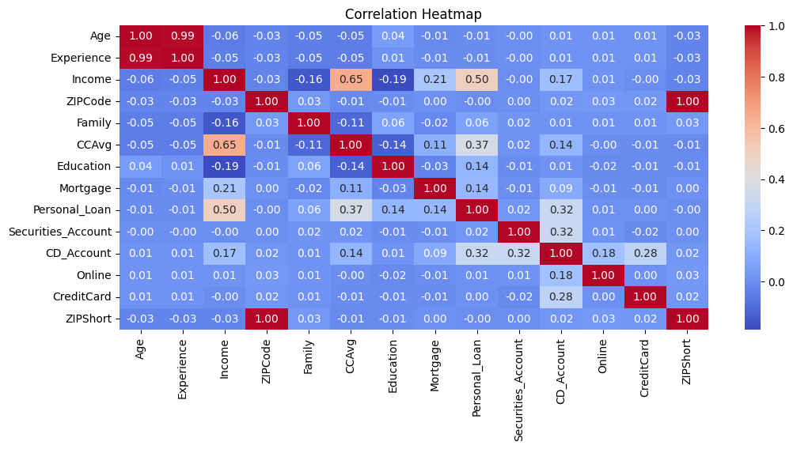

```python
# Set the figure size for the Correlation Heatmap plot
plt.figure(figsize=(12, 5))
sns.heatmap(data.corr(), annot=True, fmt=".2f", cmap='coolwarm')
plt.title('Correlation Heatmap')
plt.show()
```

### **Observations**

**Age column can be dropped due to the strong correlation between age and experience**

```python
# Drop Age column
data.drop(["Age"], axis=1, inplace=True)
```

```python
# Remove Age column in the num_features
num_features.remove("Age")
```

### **Numerical (continuous) variables and scatter plot**

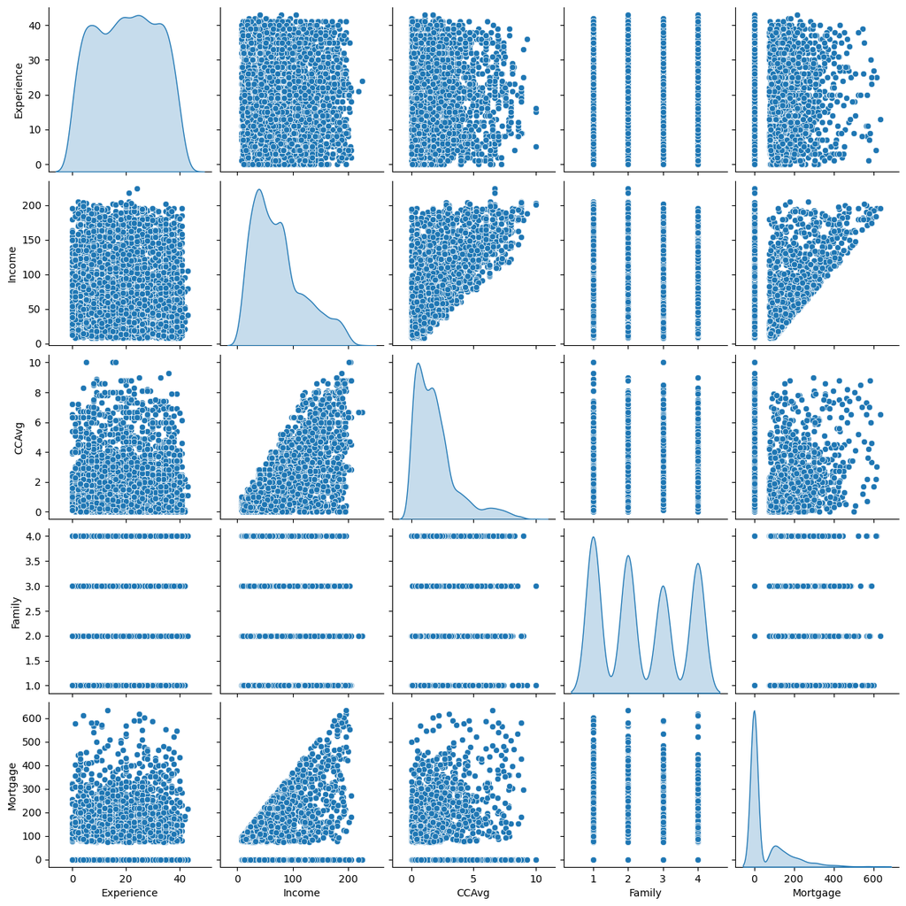

```python
# Scatter plot matrix
plt.figure(figsize=(15, 10))
sns.pairplot(data[num_features], diag_kind='kde')
plt.show()
```

### **ZIPShort and Personal Loan using count plots**

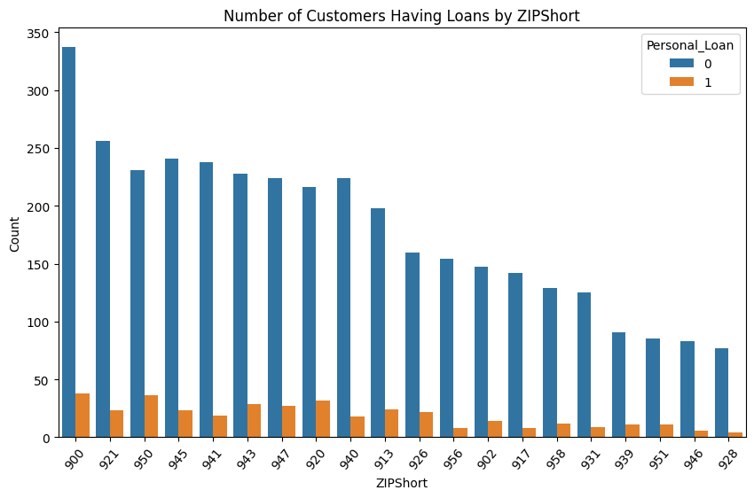

```python
ZIPShort_Cnt = data['ZIPShort'].value_counts()

# Plot number of customers having loans by ZIPShort data
plt.figure(figsize=(10, 6))
sns.countplot(data=data, x='ZIPShort', hue='Personal_Loan', order=ZIPShort_Cnt.head(20).index)
plt.xlabel('ZIPShort')
plt.xticks(rotation=50)
plt.ylabel('Count')
plt.title('Number of Customers Having Loans by ZIPShort')
plt.show()
```

### **Observations**

- There are 57 distinct ZIPShort after encoding
- ZIPShort (900, 950, 920) showing high conversion count than average count.
- ZIPShort 900 has high customer conversion count.

### **ZIPCode Drop**

- Based on the previous analysis, Hereafter ZIPCode column may cause overfitting in the analysis. Newly derived ZIPShort column will be used in the further analysis instead of ZIPCode. Hence dropping ZIPCode column

```python
# Drop ZIPCode column
data.drop(["ZIPCode"], axis=1, inplace=True)
data.head()
```

|  | Experience | Income | Family | CCAvg | Education | Mortgage | Personal_Loan | Securities_Account | CD_Account | Online | CreditCard | ZIPShort |
| --- | --- | --- | --- | --- | --- | --- | --- | --- | --- | --- | --- | --- |
| 0 | 1 | 49 | 4 | 1.6 | 1 | 0 | 0 | 1 | 0 | 0 | 0 | 911 |
| 1 | 19 | 34 | 3 | 1.5 | 1 | 0 | 0 | 1 | 0 | 0 | 0 | 900 |
| 2 | 15 | 11 | 1 | 1.0 | 1 | 0 | 0 | 0 | 0 | 0 | 0 | 947 |
| 3 | 9 | 100 | 1 | 2.7 | 2 | 0 | 0 | 0 | 0 | 0 | 0 | 941 |
| 4 | 8 | 45 | 4 | 1.0 | 2 | 0 | 0 | 0 | 0 | 0 | 1 | 913 |

### **Different Questions and its Analysis**

### **Question 1**

What is the distribution of mortgage attribute? Are there any noticeable patterns or outliers in the distribution?

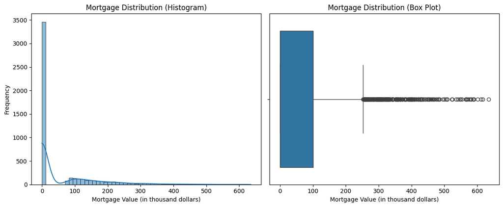

```python
plt.figure(figsize=(12, 5))

# Mortage Distribution histplot
plt.subplot(1, 2, 1)
sns.histplot(data['Mortgage'], kde=True)
plt.title('Mortgage Distribution (Histogram)')
plt.xlabel('Mortgage Value (in thousand dollars)')
plt.ylabel('Frequency')

# Mortage Distribution boxplot
plt.subplot(1, 2, 2)
sns.boxplot(x=data['Mortgage'])
plt.title('Mortgage Distribution (Box Plot)')
plt.xlabel('Mortgage Value (in thousand dollars)')

plt.tight_layout()
plt.show()
```

### **Observations**

- **Highly Skewed**: The distribution is heavily right-skewed, with a large concentration of customers having a mortgage value of zero.
- **Zero Mortgages**: A significant portion of the customer base (as indicated by the tall bar at 0 in the histogram and the bulk of the data near 0 in the box plot) has no mortgage.
- **Outliers**: For customers who do have mortgages, there's a wide range of values, and the box plot clearly shows several outliers with exceptionally high mortgage amounts.
- **Patterns**: The histogram suggests a rapid decline in frequency as mortgage values increase from zero, indicating fewer customers with higher mortgage values.

### **Question 2**

How many customers have credit cards?

```
Credit Card Distribution (0: No, 1: Yes):
CreditCard
0    3530
1    1470
Name: count, dtype: int64
```

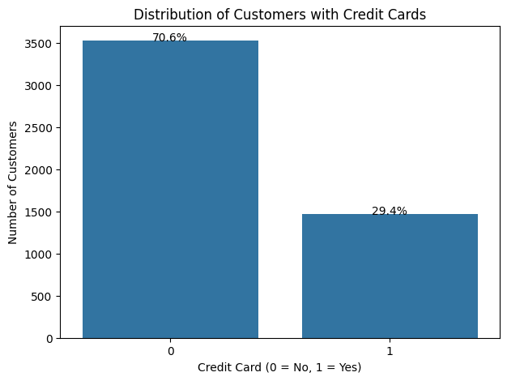

```python
# Calculate the count of customers with and without credit cards
credit_card_counts = data['CreditCard'].value_counts()

print("Credit Card Distribution (0: No, 1: Yes):")
print(credit_card_counts)

# Plot the distribution as countplot
plt.figure(figsize=(7, 5))
ax = sns.countplot(data=data, x='CreditCard')
plt.title('Distribution of Customers with Credit Cards')
plt.xlabel('Credit Card (0 = No, 1 = Yes)')
plt.ylabel('Number of Customers')

# Add percentage labels on top of each bar
total = len(data)
for p in ax.patches:
    percentage = '{:.1f}%'.format(100 * p.get_height()/total)
    x = p.get_x() + p.get_width() / 2
    y = p.get_height()
    plt.annotate(percentage, (x, y), ha='center')

plt.show()
```

### **Observations**

- **Total Customers**: Out of 5000 customers in the dataset:
  - **1470 customers (29.4%)** have a credit card issued.
  - **3530 customers (70.6%)** do not have a credit card issued.
- **Majority Without Credit Cards**: A significant majority of customers (70.6%) do not use a credit card.
- **Minority With Credit Cards**: Less than one-third of the customers (29.4%) have credit card.

### **Question 3**

What are the attributes that have a strong correlation with the target attribute (personal loan)?

### **Summary of Strong Correlations with Personal Loan**

Based on the correlation heatmap and bivariate analysis, the two attributes with the strongest positive correlation to 'Personal_Loan' are **Income** and **CCAvg**.

### **Income vs. Personal Loan**

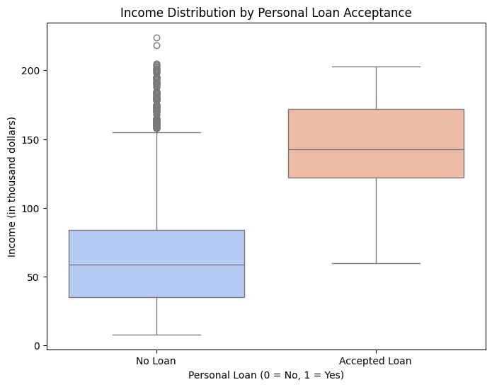

```python
# Boxplot of personal_Loan with Income analysis
plt.figure(figsize=(8, 6))
sns.boxplot(data=data, x='Personal_Loan', y='Income', palette='coolwarm')
plt.title('Income Distribution by Personal Loan Acceptance')
plt.xlabel('Personal Loan (0 = No, 1 = Yes)')
plt.ylabel('Income (in thousand dollars)')
plt.xticks(ticks=[0, 1], labels=['No Loan', 'Accepted Loan'])
plt.show()
```

### **Observations**

- **Higher Income**: Customers who accept personal loans tend to have significantly higher incomes than those who do not.
- **Income Distribution Shift**: The median income for loan acceptors is considerably higher, with their income distribution shifted upwards.

### **CCAvg vs. Personal Loan**

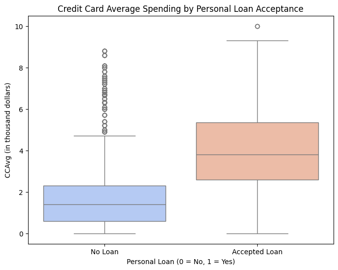

```python
# Boxplot of personal_Loan with CCAvg analysis
plt.figure(figsize=(8, 6))
sns.boxplot(data=data, x='Personal_Loan', y='CCAvg', palette='coolwarm')
plt.title('Credit Card Average Spending by Personal Loan Acceptance')
plt.xlabel('Personal Loan (0 = No, 1 = Yes)')
plt.ylabel('CCAvg (in thousand dollars)')
plt.xticks(ticks=[0, 1], labels=['No Loan', 'Accepted Loan'])
plt.show()
```

### **Observations**

- **Higher CCAvg**: Customers who accept personal loans also show a higher average credit card spending (CCAvg).
- **Spending Habits**: This suggests that customers with higher spending habits are more inclined to take a personal loan.

### **Question 4**

How does a customer's interest in purchasing a loan vary with their education?

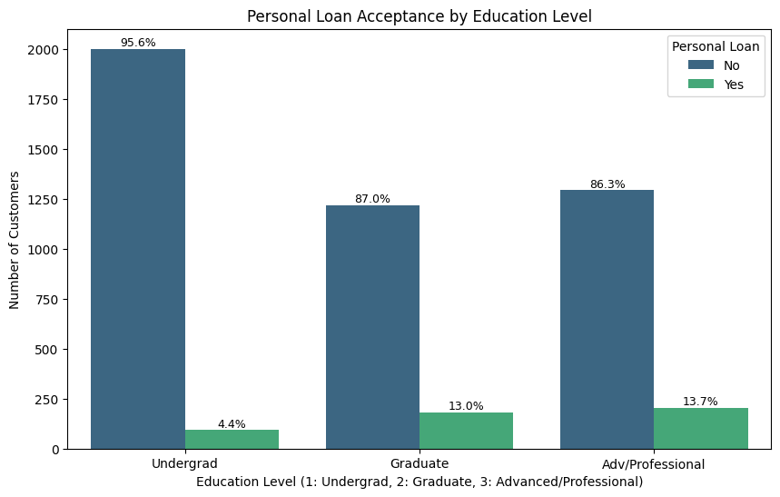

```python
# Count plot of Education vs Personal loan analysis
plt.figure(figsize=(10, 6))
ax = sns.countplot(data=data, x='Education', hue='Personal_Loan', palette='viridis')
plt.title('Personal Loan Acceptance by Education Level')
plt.xlabel('Education Level (1: Undergrad, 2: Graduate, 3: Advanced/Professional)')
plt.ylabel('Number of Customers')
plt.xticks(ticks=[0, 1, 2], labels=['Undergrad', 'Graduate', 'Adv/Professional'])

# Add percentage labels on top of each bar within each group
for p in ax.patches:
    height = p.get_height()
    if height > 0:
        # Calculate the total for this 'Education' category to get percentage of loan acceptance within that category
        education_level = int(p.get_x() + 0.5) # Approximate education level from x-coordinate
        personal_loan_status = 1 if '1' in str(p.get_facecolor()) else 0 # Crude way to check hue

        # Need to calculate total for each education level
        if education_level == 0: # Undergrad
            total_for_education = data[data['Education'] == 1].shape[0]
        elif education_level == 1: # Graduate
            total_for_education = data[data['Education'] == 2].shape[0]
        elif education_level == 2: # Advanced/Professional
            total_for_education = data[data['Education'] == 3].shape[0]
        else:
            total_for_education = 1 # Fallback to avoid division by zero

        percentage = '{:.1f}%'.format(100 * height / total_for_education)
        ax.annotate(percentage, (p.get_x() + p.get_width() / 2., height),
                    ha='center', va='bottom', fontsize=9, color='black')

plt.legend(title='Personal Loan', labels=['No', 'Yes'])
plt.show()
```

### **Observations**

- **Higher Education, Higher Loan Acceptance**: Customers with Advanced/Professional and Graduate education levels show a noticeably higher proportion of personal loan acceptance compared to Undergraduates.
  - For Undergraduates, the percentage of loan takers is significantly lower.
  - For Graduate and Advanced/Professional, the proportion of 'Yes' to 'No' for personal loan is visibly larger.
- **Education as a Key Factor**: This plot strongly suggests that education level is a significant factor in determining a customer's interest in or eligibility for a personal loan.
- **Targeting Strategy**: Marketing efforts for personal loans could be more effectively targeted towards customers with higher education levels, as they exhibit a greater propensity to accept the loan offer.

### **Question 5**

How does a customer's interest in purchasing a loan vary with their age?

The Age column was already dropped in our analysis because it had very strong correlation with 'Experience'. So we will analyse how purchasing a loan varies with customers Experience level.

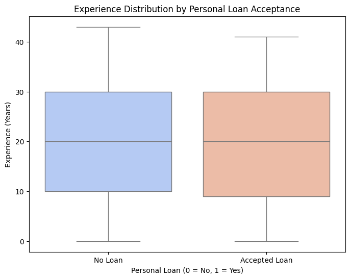

```python
plt.figure(figsize=(8, 6))
sns.boxplot(data=data, x='Personal_Loan', y='Experience', palette='coolwarm')
plt.title('Experience Distribution by Personal Loan Acceptance')
plt.xlabel('Personal Loan (0 = No, 1 = Yes)')
plt.ylabel('Experience (Years)')
plt.xticks(ticks=[0, 1], labels=['No Loan', 'Accepted Loan'])
plt.show()
```

### **Observations**

- **Similar Experience Levels**: The box plot shows that the median experience level for customers who accepted a personal loan is very similar to those who did not. The interquartile ranges also largely overlap.
- **No Strong Direct Relationship**: Unlike 'Income' and 'CCAvg', 'Experience' does not appear to be a strong differentiator for personal loan acceptance. Customers across various experience levels accept or reject loans.
- **Wide Distribution**: Both groups (loan accepted and loan not accepted) show a wide distribution of experience, indicating that customers of all experience levels are present in both categories.

### **Data Pre-Processing and Cleanup Cont.**

### **Missing value**

There are no missing values in the given data

### **Data Cleansing**

- **Experience** column had some negative values. Already processed earlier to avoid misleading analysis.
- **Age** column had strong correlation with **Experience** column. Due to this, we already dropped **Age** column
- **ZIPCode** was uneven and also too sparse. we already checked the unique counts and done the encoding to make it more efficient and less sparse.

### **Outlier Detection and Analysis**

Outlier detection is used primarily to improve data quality during preprocessing and to flag critical anomalies.

It ensures models are trained on representative data while enabling the real-time detection of high-value events

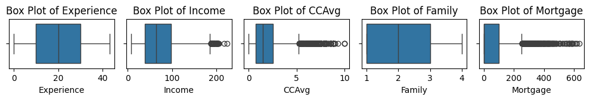

```python
# Outlier detection with boxplot
plt.figure(figsize=(10, 7))

for i, feature in enumerate(num_features):
    plt.subplot(5, 5, i + 1)
    sns.boxplot(data=data, x=feature)
    plt.title(f'Box Plot of {feature}')
    plt.xlabel(feature)
    plt.tight_layout()

plt.show()
```

### **Observations**

Based on the box plots for the numerical features:

- **Experience**: No significant outliers observed.
- **Income**: Numerous outliers on the higher end.
- **CCAvg**: Many outliers on the higher side.
- **Family**: No outliers.
- **Mortgage**: Many outliers on the higher side, for customers with non-zero mortgage values.

### **Data Preparation for Modelling**

#### **Dependent and independent variables**

```python
# defining the explanatory (independent) and response (dependent) variables
X = data.drop(["Personal_Loan"], axis=1)
y = data["Personal_Loan"]
```

### **One hot encoding**

```python
# One-hot encode Education, Family and ZIPShort
X = pd.get_dummies(X, columns=['Education', 'Family', 'ZIPShort'], drop_first=True)
# Data type manage to float
X = X.astype(float)
# print head of training data
X.head()
```

|  | Experience | Income | CCAvg | Mortgage | Securities_Account | CD_Account | Online | CreditCard | Education_2 | Education_3 | ... | ZIPShort_953 | ZIPShort_954 | ZIPShort_955 | ZIPShort_956 | ZIPShort_957 | ZIPShort_958 | ZIPShort_959 | ZIPShort_960 | ZIPShort_961 | ZIPShort_966 |
| --- | --- | --- | --- | --- | --- | --- | --- | --- | --- | --- | --- | --- | --- | --- | --- | --- | --- | --- | --- | --- | --- |
| 0 | 1.0 | 49.0 | 1.6 | 0.0 | 1.0 | 0.0 | 0.0 | 0.0 | 0.0 | 0.0 | ... | 0.0 | 0.0 | 0.0 | 0.0 | 0.0 | 0.0 | 0.0 | 0.0 | 0.0 | 0.0 |
| 1 | 19.0 | 34.0 | 1.5 | 0.0 | 1.0 | 0.0 | 0.0 | 0.0 | 0.0 | 0.0 | ... | 0.0 | 0.0 | 0.0 | 0.0 | 0.0 | 0.0 | 0.0 | 0.0 | 0.0 | 0.0 |
| 2 | 15.0 | 11.0 | 1.0 | 0.0 | 0.0 | 0.0 | 0.0 | 0.0 | 0.0 | 0.0 | ... | 0.0 | 0.0 | 0.0 | 0.0 | 0.0 | 0.0 | 0.0 | 0.0 | 0.0 | 0.0 |
| 3 | 9.0 | 100.0 | 2.7 | 0.0 | 0.0 | 0.0 | 0.0 | 0.0 | 1.0 | 0.0 | ... | 0.0 | 0.0 | 0.0 | 0.0 | 0.0 | 0.0 | 0.0 | 0.0 | 0.0 | 0.0 |
| 4 | 8.0 | 45.0 | 1.0 | 0.0 | 0.0 | 0.0 | 0.0 | 1.0 | 1.0 | 0.0 | ... | 0.0 | 0.0 | 0.0 | 0.0 | 0.0 | 0.0 | 0.0 | 0.0 | 0.0 | 0.0 |

5 rows × 69 columns

### **Split data - Training and Testing data**

- Splitting the data into training and testing sets is crucial to evaluate the performance of our machine learning model on unseen data and prevent overfitting.
- A common split ratio is 70-80% for training and 20-30% for testing. We will determine an appropriate split for our model.
- **Stratification** - Given that the target variable `Personal_Loan` is highly imbalanced (only 9.60% of customers accepted a loan), it is essential to use `stratify=y` during the split. This ensures that both the training and testing sets maintain the same proportion of loan acceptors as the original dataset, leading to a more reliable model evaluation.

```python
# Print the percentage of 1 and 0 in Personal_Loan attribute
print ("Percentage of classes in total data set of target variable Personal_Loan:")
print (y.value_counts(normalize=True)*100, '\n')

# Split the data in 70:30 ration to train and test data sets
# Stratification ensures the training and test sets having similar distribution of response
X_train, X_test, y_train, y_test = train_test_split(X, y, test_size=0.3, random_state=42, stratify=y)

print("Shape of training set : ", X_train.shape)
print("Shape of test set     : ", X_test.shape, '\n')

print("Percentage of classes in training data set of target variable Personal_Loan:")
print (y_train.value_counts(normalize=True)*100, '\n')

print("Percentage of classes in test data set of target variable Personal_Loan:")
print (y_test.value_counts(normalize=True)*100)
```

```
Percentage of classes in total data set of target variable Personal_Loan:
Personal_Loan
0    90.4
1     9.6
Name: proportion, dtype: float64

Shape of training set :  (3500, 69)
Shape of test set     :  (1500, 69)

Percentage of classes in training data set of target variable Personal_Loan:
Personal_Loan
0    90.4
1     9.6
Name: proportion, dtype: float64

Percentage of classes in test data set of target variable Personal_Loan:
Personal_Loan
0    90.4
1     9.6
Name: proportion, dtype: float64
```

### **Observation**

- **Data Split**: 70% for training (3500 samples), 30% for testing (1500 samples).
- **Imbalanced Target**: `Personal_Loan` is highly imbalanced (9.6% acceptance).
- **Stratification**: `stratify=y` successfully maintained this 90.4% vs 9.6% class distribution in both train and test sets, ensuring reliable model evaluation.

### **Model build - Decision Tree**

### **Model Building**

### **Model Evaluation Criterion**

### Model can make wrong predictions as,

- **False Positive (FP)** - The model incorrectly predicts a customer will take a loan when they actually won't.
- **False Negative (FN)** - The model incorrectly predicts a customer won't take a loan when they actually would have.

### Which case is more important?

- Losing a potential customer by predicting that the customer will not be taking the personal loan but in reality the customer was going to take the personal loan
- If model predicts the customer will purchase a personal loan, but in reality if customer does not, Then bank has to bear the money spent on marketing and others.

### **Reduce Losses?**

Recall helps prevent the loss of potential high-priority customers, while the F1 score helps optimize for both False Positives and False Negatives.

we are going to use Recall as our **model evaluation criteria** to reduce the false negatives

1. Minimize False Negatives - This ensures that qualified potential loan customers are not incorrectly overlooked.
2. Maximize Customer Reach - This enables the bank to identify and engage the highest possible number of loan-eligible customers.

   The bank would want the recall to be maximized, the greater the recall score is, the higher are the chances of minimizing the False Negatives.

### **Model Utility Functions**

1. **model_performance_classification_sklearn** function - to check the model performance of models
2. **confusion_matrix_sklearn** function - to plot the confusion matrix

### **model_performance_classification_sklearn**

```python
# defining a function to compute different metrics to check performance of a classification model built using sklearn
def model_performance_classification_sklearn(model, predictors, target):

    # predicting using the independent variables
    pred = model.predict(predictors)

    acc = accuracy_score(target, pred)
    recall = recall_score(target, pred)
    precision = precision_score(target, pred)
    f1 = f1_score(target, pred)

    # creating a dataframe of metrics
    df_perf = pd.DataFrame({
        'Metric': ['Accuracy', 'Recall', 'Precision', 'F1 Score'],
        'Score': [acc, recall, precision, f1]
    })

    return df_perf
```

### **confusion_matrix_sklearn**

```python
# defining a funtion to compute confusion matrix
def confusion_matrix_sklearn(model, predictors, target):

    # predicting using the independent variables
    pred = model.predict(predictors)

    # confusion matrix
    cm = confusion_matrix(target, pred)

    # create labels for each cell in the confusion matrix with both count and percentage
    labels = np.asarray(
        [
            ["{0:0.0f}".format(item) + "\n{0:.2%}".format(item / cm.flatten().sum())]
            for item in cm.flatten()
        ]
    ).reshape(2, 2)

    plt.figure(figsize=(8,6))

    sns.heatmap(cm, annot=labels, fmt='')
    plt.ylabel('True label')
    plt.xlabel('Predicted label')
    plt.title('Confusion Matrix')
    plt.show()
```

### **Decision Tree (sklearn default)**

```python
# create instance of the decision tree model
dt_model = DecisionTreeClassifier(random_state=42)

# fit the model on the training data
dt_model.fit(X_train, y_train)
```

```
DecisionTreeClassifier(random_state=42)
```

### Model Evaluation

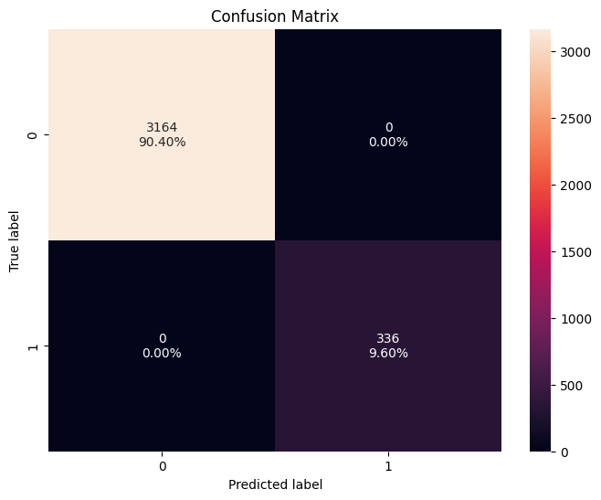

```python
# Plot confusion matrix with training data
confusion_matrix_sklearn(dt_model, X_train, y_train)
```

```python
# Model performance classification metrics on training data set
dtree1_train_performance = model_performance_classification_sklearn(dt_model, X_train, y_train)
dtree1_train_performance
```

|  | Metric | Score |
| --- | --- | --- |
| 0 | Accuracy | 1.0 |
| 1 | Recall | 1.0 |
| 2 | Precision | 1.0 |
| 3 | F1 Score | 1.0 |

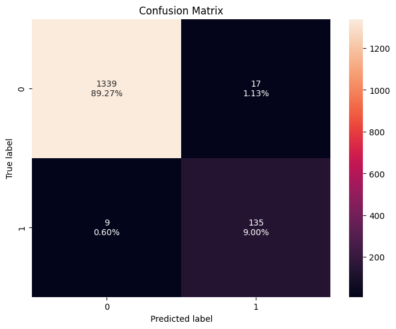

```python
# Plot confusion matrix with test data set
confusion_matrix_sklearn(dt_model, X_test, y_test)
```

```python
# Model performance classification metrics on test data set
dtree1_test_performance = model_performance_classification_sklearn(dt_model, X_test, y_test)
dtree1_test_performance
```

|  | Metric | Score |
| --- | --- | --- |
| 0 | Accuracy | 0.982667 |
| 1 | Recall | 0.937500 |
| 2 | Precision | 0.888158 |
| 3 | F1 Score | 0.912162 |

### **Model Performance**

- **Training Set Performance**:
  - **Accuracy**: 1.0 (100%)
  - **Recall**: 1.0 (100%)
  - **Precision**: 1.0 (100%)
  - **F1 Score**: 1.0 (100%)
- **Test Set Performance**:
  - **Accuracy**: 0.9827 (98.27%)
  - **Recall**: 0.9375 (93.75%)
  - **Precision**: 0.8882 (88.82%)
  - **F1 Score**: 0.9122 (91.22%)

### **Model Performance Summary**

The model achieved perfect scores on the training set, indicating that it learned the training data extremely well. However, there is a slight drop in performance on the test set, particularly in precision and F1 score, though recall remains high. This suggests potential overfitting to the training data, which is common for unoptimized Decision Trees. The high recall on the test set (93.75%) is a positive sign, as our primary evaluation criterion is to minimize False Negatives.

### **Visualizing dtree1**

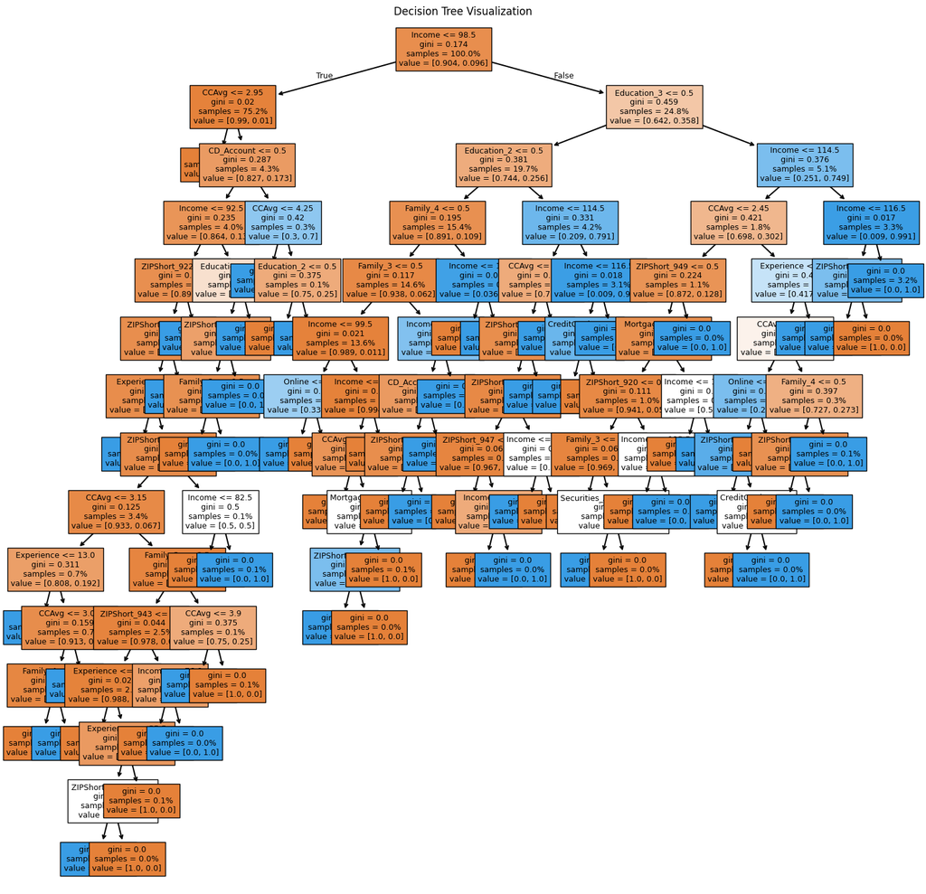

```python
# Feature names in X_train
feature_names = list(X_train.columns)

# Plotting the decision tree
plt.figure(figsize=(18, 18))
out = tree.plot_tree(dt_model, feature_names=feature_names, filled=True, fontsize=9, node_ids=False, class_names=None, proportion=True)
plt.title("Decision Tree Visualization")

# Adding arrows in the decision tree
for o in out:
  arrow = o.arrow_patch
  if arrow is not None:
    arrow.set_edgecolor('black')
    arrow.set_linewidth(1.5)
plt.show()
```

### **Observations**

- **Deep Tree**: The tree is very deep, suggesting potential overfitting to the training data.
- **Key Feature**: **Income** is a crucial splitting feature at higher levels.
- **Pure Leaves**: Many leaf nodes are pure, which also indicates overfitting.
- **Complexity**: The tree's depth makes it challenging to interpret fully.

```python
# Print text report showing the decision tree rules.
print(tree.export_text(dt_model, feature_names=feature_names, show_weights=True))
```

```
|--- Income <= 98.50
|   |--- CCAvg <= 2.95
|   |   |--- weights: [2483.00, 0.00] class: 0
|   |--- CCAvg >  2.95
|   |   |--- CD_Account <= 0.50
|   |   |   |--- Income <= 92.50
|   |   |   |   |--- ZIPShort_922 <= 0.50
|   |   |   |   |   |--- ZIPShort_912 <= 0.50
|   |   |   |   |   |   |--- Experience <= 0.50
|   |   |   |   |   |   |   |--- weights: [0.00, 1.00] class: 1
|   |   |   |   |   |   |--- Experience >  0.50
|   |   |   |   |   |   |   |--- ZIPShort_941 <= 0.50
|   |   |   |   |   |   |   |   |--- CCAvg <= 3.15
|   |   |   |   |   |   |   |   |   |--- Experience <= 13.00
|   |   |   |   |   |   |   |   |   |   |--- weights: [0.00, 3.00] class: 1
|   |   |   |   |   |   |   |   |   |--- Experience >  13.00
|   |   |   |   |   |   |   |   |   |   |--- CCAvg <= 3.05
|   |   |   |   |   |   |   |   |   |   |   |--- truncated branch of depth 2
|   |   |   |   |   |   |   |   |   |   |--- CCAvg >  3.05
|   |   |   |   |   |   |   |   |   |   |   |--- weights: [0.00, 1.00] class: 1
|   |   |   |   |   |   |   |   |--- CCAvg >  3.15
|   |   |   |   |   |   |   |   |   |--- Family_3 <= 0.50
|   |   |   |   |   |   |   |   |   |   |--- ZIPShort_943 <= 0.50
|   |   |   |   |   |   |   |   |   |   |   |--- truncated branch of depth 4
|   |   |   |   |   |   |   |   |   |   |--- ZIPShort_943 >  0.50
|   |   |   |   |   |   |   |   |   |   |   |--- truncated branch of depth 2
|   |   |   |   |   |   |   |   |   |--- Family_3 >  0.50
|   |   |   |   |   |   |   |   |   |   |--- CCAvg <= 3.90
|   |   |   |   |   |   |   |   |   |   |   |--- weights: [0.00, 1.00] class: 1
|   |   |   |   |   |   |   |   |   |   |--- CCAvg >  3.90
|   |   |   |   |   |   |   |   |   |   |   |--- weights: [3.00, 0.00] class: 0
|   |   |   |   |   |   |   |--- ZIPShort_941 >  0.50
|   |   |   |   |   |   |   |   |--- Income <= 82.50
|   |   |   |   |   |   |   |   |   |--- weights: [2.00, 0.00] class: 0
|   |   |   |   |   |   |   |   |--- Income >  82.50
|   |   |   |   |   |   |   |   |   |--- weights: [0.00, 2.00] class: 1
|   |   |   |   |   |--- ZIPShort_912 >  0.50
|   |   |   |   |   |   |--- weights: [0.00, 1.00] class: 1
|   |   |   |   |--- ZIPShort_922 >  0.50
|   |   |   |   |   |--- weights: [0.00, 1.00] class: 1
```

[output cut: 129 more lines]

```
|   |   |   |   |   |   |   |   |--- weights: [8.00, 0.00] class: 0
|   |   |   |   |   |   |   |--- ZIPShort_941 >  0.50
|   |   |   |   |   |   |   |   |--- weights: [0.00, 1.00] class: 1
|   |   |   |   |   |   |--- Family_4 >  0.50
|   |   |   |   |   |   |   |--- weights: [0.00, 2.00] class: 1
|   |   |   |   |--- Experience >  24.00
|   |   |   |   |   |--- weights: [0.00, 5.00] class: 1
|   |   |--- Income >  114.50
|   |   |   |--- Income <= 116.50
|   |   |   |   |--- ZIPShort_913 <= 0.50
|   |   |   |   |   |--- weights: [0.00, 3.00] class: 1
|   |   |   |   |--- ZIPShort_913 >  0.50
|   |   |   |   |   |--- weights: [1.00, 0.00] class: 0
|   |   |   |--- Income >  116.50
|   |   |   |   |--- weights: [0.00, 112.00] class: 1
```

### **Model Performance Evaluation and Improvement**

### **Decision Tree (With Class Weights)**

Because of the dataset is imbalanced—with "No Loan" cases significantly outnumbering "Loan Accepted" cases. A standard Decision Tree may become biased toward the majority class. By setting class_weight="balanced", the model assigns greater importance to the minority "Loan Accepted" class, ensuring it is not overlooked during training.

```python
# Create the decision tree model with class_weight hyper parameter
dt2_model = DecisionTreeClassifier(random_state=1, class_weight="balanced")

# Fit the model on the training data
dt2_model.fit(X_train, y_train)
```

```
DecisionTreeClassifier(class_weight='balanced', random_state=1)
```

### **Model evaluation**

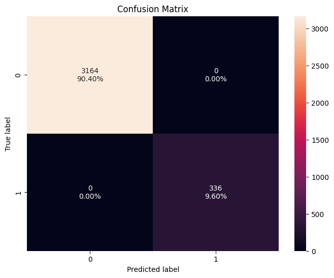

```python
# Plot confusion matrix with training data
confusion_matrix_sklearn(dt2_model, X_train, y_train)
```

```python
# Model performance classification metrics on training data set
dtree2_train_performance = model_performance_classification_sklearn(dt2_model, X_train, y_train)
dtree2_train_performance
```

|  | Metric | Score |
| --- | --- | --- |
| 0 | Accuracy | 1.0 |
| 1 | Recall | 1.0 |
| 2 | Precision | 1.0 |
| 3 | F1 Score | 1.0 |

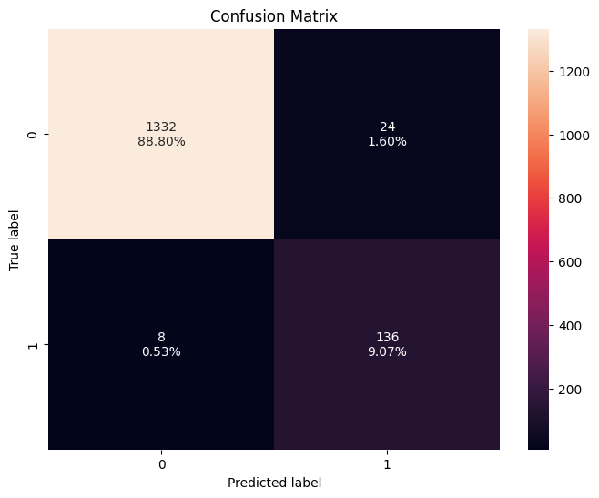

```python
# Plot confusion matrix with test data set
confusion_matrix_sklearn(dt2_model, X_test, y_test)
```

```python
# Model performance classification metrics on test data set
dtree2_test_performance = model_performance_classification_sklearn(dt2_model, X_test, y_test)
dtree2_test_performance
```

|  | Metric | Score |
| --- | --- | --- |
| 0 | Accuracy | 0.978667 |
| 1 | Recall | 0.944444 |
| 2 | Precision | 0.850000 |
| 3 | F1 Score | 0.894737 |

### **Model Performance Summary (Decision Tree with Class Weights)**

**Decision Tree Classifier (class_weight="balanced")**

- **Training Set Performance**:
  - **Accuracy**: 1.0 (100%)
  - **Recall**: 1.0 (100%)
  - **Precision**: 1.0 (100%)
  - **F1 Score**: 1.0 (100%)
- **Test Set Performance**:
  - **Accuracy**: 0.9787 (97.87%)
  - **Recall**: 0.9444 (94.44%)
  - **Precision**: 0.8500 (85.00%)
  - **F1 Score**: 0.8947 (89.47%)

### **Model Performance Summary**

Setting `class_weight="balanced"` has resulted in a slightly lower accuracy and precision on the test set compared to the default Decision Tree model. However, it has successfully **increased the recall score from 93.75% to 94.44%**, which is our primary evaluation metric. This indicates that the model is now better at identifying positive cases (customers who will accept the loan), aligning with our objective to minimize false negatives and maximize customer reach. The trade-off in precision suggests a slight increase in false positives, but this is acceptable given our business objective to prioritize identifying potential loan customers.

### **Visualizing dtree2**

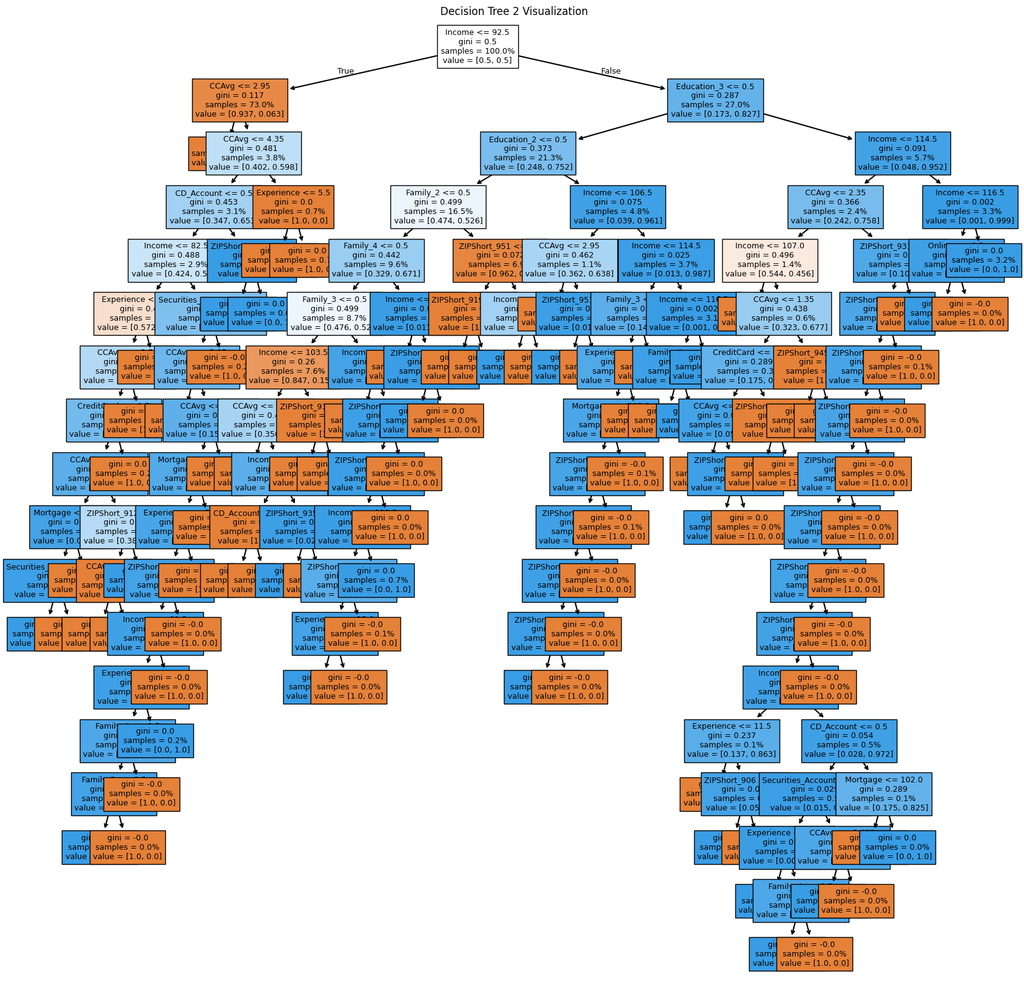

```python
# Feature names in X_train
feature_names = list(X_train.columns)

# Plotting the decision tree
plt.figure(figsize=(20, 20))
out = tree.plot_tree(dt2_model, feature_names=feature_names, filled=True, fontsize=9, node_ids=False, class_names=None, proportion=True)
plt.title("Decision Tree 2 Visualization")

# Adding arrows in the decision tree
for o in out:
  arrow = o.arrow_patch
  if arrow is not None:
    arrow.set_edgecolor('black')
    arrow.set_linewidth(1.5)
plt.show()
```

### **Observations**

- **Deep Tree (Similar to dtree1)**: The tree remains deep, still indicating a high level of complexity and potential for overfitting, similar to the `dtree1` model.
- **Key Feature (`Income`)**: `Income` continues to be a crucial splitting feature at higher levels, consistent with `dtree1` observations.
- **Impact of `class_weight`**: While visually similar in depth, the `class_weight="balanced"` parameter subtly influences the splitting criteria. It forces the model to pay more attention to the minority class (`Personal_Loan=1`), which is reflected in the improved recall score on the test set, even if the overall tree structure still looks complex.
- **Pure Leaves/Complexity**: Many pure leaf nodes still exist, but the internal decision logic is now biased towards correctly classifying the minority class, which is a key objective for this model.

```python
# Print text report showing the decision tree 2 rules.
print(tree.export_text(dt2_model, feature_names=feature_names, show_weights=True))
```

```
|--- Income <= 92.50
|   |--- CCAvg <= 2.95
|   |   |--- weights: [1339.60, 0.00] class: 0
|   |--- CCAvg >  2.95
|   |   |--- CCAvg <= 4.35
|   |   |   |--- CD_Account <= 0.50
|   |   |   |   |--- Income <= 82.50
|   |   |   |   |   |--- Experience <= 18.50
|   |   |   |   |   |   |--- CCAvg <= 3.55
|   |   |   |   |   |   |   |--- CreditCard <= 0.50
|   |   |   |   |   |   |   |   |--- CCAvg <= 3.15
|   |   |   |   |   |   |   |   |   |--- Mortgage <= 249.50
|   |   |   |   |   |   |   |   |   |   |--- Securities_Account <= 0.50
|   |   |   |   |   |   |   |   |   |   |   |--- weights: [0.00, 20.83] class: 1
|   |   |   |   |   |   |   |   |   |   |--- Securities_Account >  0.50
|   |   |   |   |   |   |   |   |   |   |   |--- weights: [0.55, 0.00] class: 0
|   |   |   |   |   |   |   |   |   |--- Mortgage >  249.50
|   |   |   |   |   |   |   |   |   |   |--- weights: [0.55, 0.00] class: 0
|   |   |   |   |   |   |   |   |--- CCAvg >  3.15
|   |   |   |   |   |   |   |   |   |--- ZIPShort_912 <= 0.50
|   |   |   |   |   |   |   |   |   |   |--- CCAvg <= 3.30
|   |   |   |   |   |   |   |   |   |   |   |--- weights: [1.66, 0.00] class: 0
|   |   |   |   |   |   |   |   |   |   |--- CCAvg >  3.30
|   |   |   |   |   |   |   |   |   |   |   |--- weights: [1.66, 0.00] class: 0
|   |   |   |   |   |   |   |   |   |--- ZIPShort_912 >  0.50
|   |   |   |   |   |   |   |   |   |   |--- weights: [0.00, 5.21] class: 1
|   |   |   |   |   |   |   |--- CreditCard >  0.50
|   |   |   |   |   |   |   |   |--- weights: [3.32, 0.00] class: 0
|   |   |   |   |   |   |--- CCAvg >  3.55
|   |   |   |   |   |   |   |--- weights: [8.30, 0.00] class: 0
|   |   |   |   |   |--- Experience >  18.50
|   |   |   |   |   |   |--- weights: [18.81, 0.00] class: 0
|   |   |   |   |--- Income >  82.50
|   |   |   |   |   |--- Securities_Account <= 0.50
|   |   |   |   |   |   |--- CCAvg <= 3.05
|   |   |   |   |   |   |   |--- weights: [3.32, 0.00] class: 0
|   |   |   |   |   |   |--- CCAvg >  3.05
|   |   |   |   |   |   |   |--- CCAvg <= 3.95
|   |   |   |   |   |   |   |   |--- Mortgage <= 104.50
|   |   |   |   |   |   |   |   |   |--- Experience <= 35.50
```

[output cut: 162 more lines]

```
|   |   |   |   |   |   |   |   |--- weights: [0.55, 0.00] class: 0
|   |   |   |   |   |   |--- ZIPShort_902 >  0.50
|   |   |   |   |   |   |   |--- weights: [0.55, 0.00] class: 0
|   |   |   |   |   |--- ZIPShort_956 >  0.50
|   |   |   |   |   |   |--- weights: [1.11, 0.00] class: 0
|   |   |   |   |--- ZIPShort_931 >  0.50
|   |   |   |   |   |--- weights: [1.66, 0.00] class: 0
|   |   |--- Income >  114.50
|   |   |   |--- Income <= 116.50
|   |   |   |   |--- Online <= 0.50
|   |   |   |   |   |--- weights: [0.00, 15.62] class: 1
|   |   |   |   |--- Online >  0.50
|   |   |   |   |   |--- weights: [0.55, 0.00] class: 0
|   |   |   |--- Income >  116.50
|   |   |   |   |--- weights: [0.00, 583.33] class: 1
```

### **Decision Tree (Pre-Pruning)**

Pre-pruning, also known as early stopping, is a technique used to prevent overfitting by restricting the growth of a decision tree during the training process, typically by setting constraints such as maximum tree depth or minimum samples per leaf

### **Hyperparameter tuning**

- **Control Over Model Behavior**: Hyperparameters serve as essential configuration settings that dictate how a model learns and functions.
- **Manual Configuration**: Unlike standard model parameters learned automatically during training, hyperparameters must be explicitly defined beforehand.
- **Enhanced Performance**: Precise tuning improves both model accuracy and generalization, ensuring reliable predictions on new data.

```python
# Define the parameters of the tree to iterate over
max_depth_values = np.arange(2, 11, 2)
max_leaf_nodes_values = np.arange(10, 51, 5)
min_samples_split_values = np.arange(10, 51, 5)

# Variables to store best model and its performance
best_estimator = None
best_score_diff = float('inf')
best_test_score = 0.0

# Iterate over the combinations of hyperparameters
for max_depth in max_depth_values:
    for max_leaf_nodes in max_leaf_nodes_values:
        for min_samples_split in min_samples_split_values:
          estimator = DecisionTreeClassifier(
              max_depth=max_depth,
              max_leaf_nodes=max_leaf_nodes,
              min_samples_split=min_samples_split,
              random_state=1,
              class_weight="balanced"
          )

          # Fit the model to training data
          estimator.fit(X_train, y_train)

          # Make predictions on training and test dataset
          y_train_pred = estimator.predict(X_train)
          y_test_pred = estimator.predict(X_test)

          # Calculate the difference between train and test scores
          train_recall_score = recall_score(y_train, y_train_pred)
          test_recall_score = recall_score(y_test, y_test_pred)

          # Calculate the abs difference between training and test F1 scores
          score_diff = abs(train_recall_score - test_recall_score)

          # Update the best estimator and best score if current score having smaller score difference
          if (score_diff < best_score_diff) and (test_recall_score > best_test_score):
              best_estimator = estimator
              best_score_diff = score_diff

print("Best parameters found:")
print(f"max_depth: {best_estimator.max_depth}")
print(f"max_leaf_nodes: {best_estimator.max_leaf_nodes}")
print(f"min_samples_split: {best_estimator.min_samples_split}")
print(f"Best score difference: {best_score_diff}")
print(f"Best test recall score: {best_test_score}")
```

```
Best parameters found:
max_depth: 2
max_leaf_nodes: 10
min_samples_split: 10
Best score difference: 0.0
Best test recall score: 0.0
```

```python
# Creating an instance of best model
dt3_model = best_estimator

# Fit the model on the training data
dt3_model.fit(X_train, y_train)
```

```
DecisionTreeClassifier(class_weight='balanced', max_depth=np.int64(2),
                       max_leaf_nodes=np.int64(10),
                       min_samples_split=np.int64(10), random_state=1)
```

### **Model evaluation**

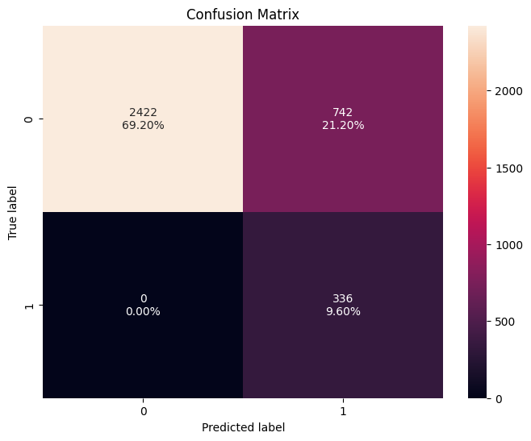

```python
# Plot confusion matrix with training data using pre-pruning
confusion_matrix_sklearn(dt3_model, X_train, y_train)
```

```python
# Model performance classification metrics on training data set using pre-pruning
dtree3_train_performance = model_performance_classification_sklearn(dt3_model, X_train, y_train)
dtree3_train_performance
```

|  | Metric | Score |
| --- | --- | --- |
| 0 | Accuracy | 0.788000 |
| 1 | Recall | 1.000000 |
| 2 | Precision | 0.311688 |
| 3 | F1 Score | 0.475248 |

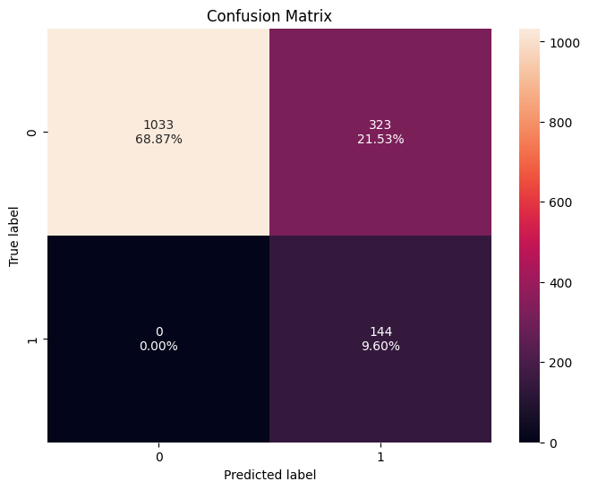

```python
# Plot confusion matrix with test data set using pre-pruning
confusion_matrix_sklearn(dt3_model, X_test, y_test)
```

```python
# Model performance classification metrics on test data set
dtree3_test_performance = model_performance_classification_sklearn(dt3_model, X_test, y_test)
dtree3_test_performance
```

|  | Metric | Score |
| --- | --- | --- |
| 0 | Accuracy | 0.784667 |
| 1 | Recall | 1.000000 |
| 2 | Precision | 0.308351 |
| 3 | F1 Score | 0.471358 |

### **Model Performance Summary**

- **Shallow & Interpretable**: Significantly shallower and more interpretable than `dtree1` and `dtree2` due to pre-pruning, indicating reduced overfitting.
- **Generalization Improved**: Training metrics (e.g., Accuracy: 0.788, Precision: 0.312) are no longer perfect, a positive sign for better generalization.
- **Perfect Recall**: Achieved excellent recall (1.0 for both train/test), effectively identifying all positive loan cases, aligning with the primary business objective.
- **Precision Trade-off**: Lower precision (Test: 0.308) and F1 Score (Test: 0.471) indicate more false positives, an acceptable trade-off for maximizing recall.

### **Visualizing dtree3**

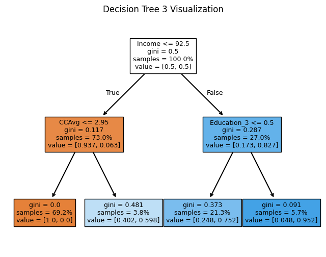

```python
# Feature names in X_train
feature_names = list(X_train.columns)

# Plotting the decision tree
plt.figure(figsize=(8, 6))
out = tree.plot_tree(dt3_model, feature_names=feature_names, filled=True, fontsize=9, node_ids=False, class_names=None, proportion=True)
plt.title("Decision Tree 3 Visualization")

# Adding arrows in the decision tree
for o in out:
  arrow = o.arrow_patch
  if arrow is not None:
    arrow.set_edgecolor('black')
    arrow.set_linewidth(1.5)
plt.show()
```

```python
# Print text report showing the decision tree 3 rules.
print(tree.export_text(dt3_model, feature_names=feature_names, show_weights=True))
```

```
|--- Income <= 92.50
|   |--- CCAvg <= 2.95
|   |   |--- weights: [1339.60, 0.00] class: 0
|   |--- CCAvg >  2.95
|   |   |--- weights: [63.05, 93.75] class: 1
|--- Income >  92.50
|   |--- Education_3 <= 0.50
|   |   |--- weights: [311.95, 947.92] class: 1
|   |--- Education_3 >  0.50
|   |   |--- weights: [35.40, 708.33] class: 1
```

### **Decision Tree (Post-Pruning)**

**Tree Size Control**: Cost complexity pruning serves as an alternative method for managing the size of a decision tree.

**Parameterization**: In DecisionTreeClassifier, this technique is controlled by the ccp_alpha cost complexity parameter.

**Pruning Intensity**: Increasing the value of ccp_alpha results in a higher number of nodes being pruned.

**Optimization**: This approach is primarily used to demonstrate how ccp_alpha regularizes trees and how to determine its optimal value.

**Total Leaf Impurity vs. Effective Alphas**: Minimal cost-complexity pruning iteratively identifies and prunes the node with the "weakest link," defined by its effective alpha value; nodes with the smallest effective alphas are removed first.

**Determining Appropriate Alphas:** To identify suitable *ccp_alpha* values, *scikit-learn* provides the *cost_complexity_pruning_path* method, which calculates the effective alphas and corresponding total leaf impurities at each stage of the pruning process.

**Regularization Effect**: As the alpha value increases, the tree undergoes more extensive pruning, resulting in higher total leaf impurity.

```python
# Create an instance of decision tree model with class_weight as balanced
clf = DecisionTreeClassifier(random_state=1, class_weight="balanced")

# Fit the model to training data
path = clf.cost_complexity_pruning_path(X_train, y_train)

# Extract the array of effective alphas and impurities from pruning path
ccp_alphas = abs(path.ccp_alphas)
impurities = path.impurities
```

```python
# Print the ccp alphas and impurities
pd.DataFrame(path)
```

|  | ccp_alphas | impurities |
| --- | --- | --- |
| 0 | 0.000000e+00 | -5.480059e-17 |
| 1 | 3.158030e-19 | -5.448479e-17 |
| 2 | 3.052762e-18 | -5.143203e-17 |
| 3 | 3.315932e-18 | -4.811610e-17 |
| 4 | 1.017587e-17 | -3.794022e-17 |
| 5 | 1.652118e-17 | -2.141905e-17 |
| 6 | 6.210793e-17 | 4.068888e-17 |
| 7 | 1.945347e-16 | 2.352235e-16 |
| 8 | 3.284351e-16 | 5.636587e-16 |
| 9 | 1.556663e-04 | 6.226650e-04 |
| 10 | 1.578711e-04 | 9.384073e-04 |
| 11 | 1.578820e-04 | 1.254171e-03 |
| 12 | 2.052545e-04 | 1.869935e-03 |
| 13 | 2.888599e-04 | 5.047394e-03 |
| 14 | 2.923583e-04 | 5.632110e-03 |
| 15 | 3.001200e-04 | 5.932230e-03 |
| 16 | 3.001200e-04 | 6.532470e-03 |
| 17 | 3.001200e-04 | 7.132711e-03 |
| 18 | 3.039514e-04 | 8.044565e-03 |
| 19 | 3.094825e-04 | 8.354047e-03 |
| 20 | 3.105590e-04 | 8.664606e-03 |
| 21 | 3.124200e-04 | 9.914286e-03 |
| 22 | 3.148615e-04 | 1.022915e-02 |
| 23 | 5.345468e-04 | 1.076369e-02 |
| 24 | 5.430277e-04 | 1.239278e-02 |
| 25 | 5.559601e-04 | 1.294874e-02 |
| 26 | 6.226385e-04 | 1.357138e-02 |
| 27 | 7.558128e-04 | 1.508300e-02 |
| 28 | 7.793076e-04 | 1.586231e-02 |
| 29 | 7.804937e-04 | 1.742330e-02 |
| 30 | 9.874515e-04 | 1.939820e-02 |
| 31 | 1.032205e-03 | 2.043040e-02 |
| 32 | 1.249414e-03 | 2.167982e-02 |
| 33 | 1.263662e-03 | 2.294348e-02 |
| 34 | 1.286987e-03 | 2.423047e-02 |
| 35 | 1.485266e-03 | 2.571573e-02 |
| 36 | 1.763938e-03 | 2.747967e-02 |
| 37 | 1.832069e-03 | 2.931174e-02 |
| 38 | 1.851745e-03 | 3.116348e-02 |
| 39 | 2.221763e-03 | 4.005054e-02 |
| 40 | 2.630971e-03 | 4.268151e-02 |
| 41 | 2.644049e-03 | 4.532556e-02 |
| 42 | 2.962264e-03 | 4.828782e-02 |
| 43 | 3.132794e-03 | 5.142062e-02 |
| 44 | 3.506278e-03 | 5.492689e-02 |
| 45 | 3.848385e-03 | 5.877528e-02 |
| 46 | 4.647764e-03 | 6.807081e-02 |
| 47 | 7.305319e-03 | 7.537613e-02 |
| 48 | 2.050775e-02 | 1.163916e-01 |
| 49 | 2.307469e-02 | 1.856157e-01 |
| 50 | 2.867322e-02 | 2.142889e-01 |
| 51 | 2.857111e-01 | 5.000000e-01 |

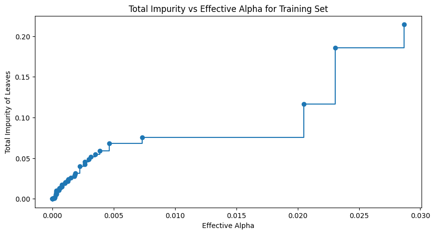

```python
# Create a figure
fix, ax = plt.subplots(figsize=(10,5))

#Plot the total impurities vs effective alphas
# Using markers at each data point and connecting them with steps
ax.plot(ccp_alphas[:-1], impurities[:-1], marker="o", drawstyle="steps-post")

#Set labels
ax.set_xlabel("Effective Alpha")
ax.set_ylabel("Total Impurity of Leaves")
ax.set_title("Total Impurity vs Effective Alpha for Training Set")
plt.show()
```

Decision tress is trained using the effective alphas. The last value in ccp_alphas that prunes the whole tree, leaving the tree, clfs[-1] with one node.

```python
# Empty list to store decision tree classsifiers
clfs = []

# Iterate each ccp_alpha extracted from cost complexity pruning path
for ccp_alpha in ccp_alphas:
  # Create an instance of decision tree model with class_weight as balanced and ccp_alpha
  clf = DecisionTreeClassifier(random_state=1, class_weight="balanced", ccp_alpha=ccp_alpha)

  # Fit the model to training data
  clf.fit(X_train, y_train)

  # Append the model to the list
  clfs.append(clf)

print("Number of nodes in the last tree is: {} with ccp_alpha: {}".format(clfs[-1].tree_.node_count, ccp_alphas[-1]))
```

```
Number of nodes in the last tree is: 1 with ccp_alpha: 0.28571108440376275
```

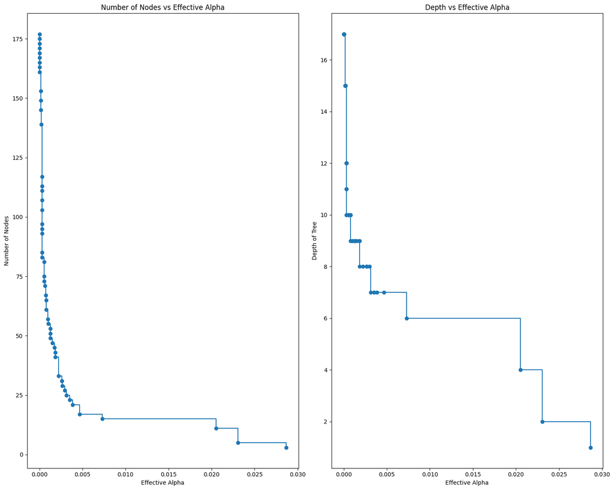

```python
# Remove the last classifier and its ccp_alpha value from the list
clfs = clfs[:-1]
ccp_alphas = ccp_alphas[:-1]

# Extract the number of nodes in each tree classifier
node_counts = [clf.tree_.node_count for clf in clfs]

# Extract the depth of each tree classifier
depths = [clf.tree_.max_depth for clf in clfs]

# Create a figure and a set of subplots
fix, ax = plt.subplots(1, 2, figsize=(15, 12))

# Plot the number of nodes versus ccp_alphas on the first subplot
ax[0].plot(ccp_alphas, node_counts, marker="o", drawstyle="steps-post")
ax[0].set_xlabel("Effective Alpha")
ax[0].set_ylabel("Number of Nodes")
ax[0].set_title("Number of Nodes vs Effective Alpha")

# Plot the depth versus ccp_alphas on the second subplot
ax[1].plot(ccp_alphas, depths, marker="o", drawstyle="steps-post")
ax[1].set_xlabel("Effective Alpha")
ax[1].set_ylabel("Depth of Tree")
ax[1].set_title("Depth vs Effective Alpha")

# Adjust the layout and display the plots
plt.tight_layout()
plt.show()
```

```python
train_recall = []

# Iterate through each decision tree classifier in 'clfs'
for clf in clfs:
  # Make predictions on the training dataset using the current decision tree classifier
  pred_train = clf.predict(X_train)

  # Calculate the recall score for the training predictions
  recall = recall_score(y_train, pred_train)

  # Append the recall score to the 'train_recall' list
  train_recall.append(recall)
```

```python
test_recall = []

# Iterate through each decision tree classifier in 'clfs'
for clf in clfs:
  # Make predictions on the test dataset using the current decision tree classifier
  pred_test = clf.predict(X_test)

  # Calculate the recall score for the test predictions
  recall = recall_score(y_test, pred_test)

  # Append the recall score to the 'test_recall' list
  test_recall.append(recall)
```

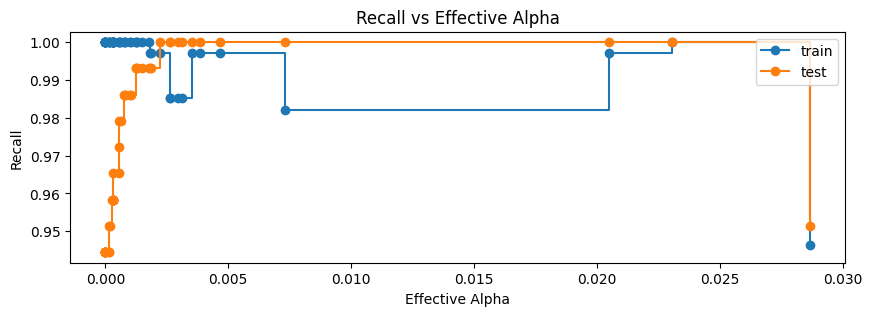

```python
fig, ax = plt.subplots(figsize=(10, 3))
# Set Labels
ax.set_xlabel("Effective Alpha")
ax.set_ylabel("Recall")
ax.set_title("Recall vs Effective Alpha")

# Plot train recall against alpha
ax.plot(ccp_alphas, train_recall, marker="o", label="train", drawstyle="steps-post")

# Plot test recall against alpha
ax.plot(ccp_alphas, test_recall, marker="o", label="test", drawstyle="steps-post")
ax.legend()
plt.show()
```

```python
# Create the model where we get the highest test F1 score
index_best_model = np.argmax(test_recall)

# selecting the decision tree model corresponds to highest test score
dt4_model = clfs[index_best_model]

print(dt4_model)
```

```
DecisionTreeClassifier(ccp_alpha=np.float64(0.002221763346296765),
                       class_weight='balanced', random_state=1)
```

### **Model evaluation**

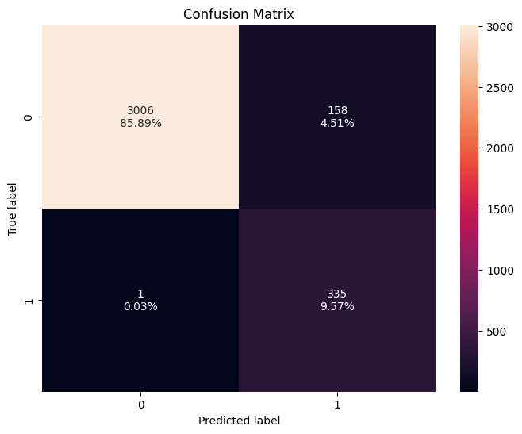

```python
# Plot confusion matrix with training data
confusion_matrix_sklearn(dt4_model, X_train, y_train)
```

```python
# Model performance classification metrics on training data set
dtree4_train_performance = model_performance_classification_sklearn(dt4_model, X_train, y_train)
dtree4_train_performance
```

|  | Metric | Score |
| --- | --- | --- |
| 0 | Accuracy | 0.954571 |
| 1 | Recall | 0.997024 |
| 2 | Precision | 0.679513 |
| 3 | F1 Score | 0.808203 |

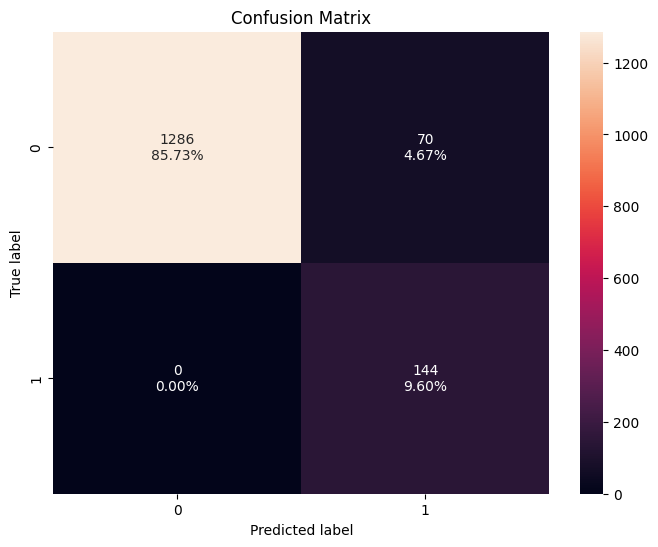

```python
# Plot confusion matrix with test data set
confusion_matrix_sklearn(dt4_model, X_test, y_test)
```

```python
# Model performance classification metrics on test data set
dtree4_test_performance = model_performance_classification_sklearn(dt4_model, X_test, y_test)
dtree4_test_performance
```

|  | Metric | Score |
| --- | --- | --- |
| 0 | Accuracy | 0.953333 |
| 1 | Recall | 1.000000 |
| 2 | Precision | 0.672897 |
| 3 | F1 Score | 0.804469 |

### **Model Performance Summary**

- **Strong, Consistent Accuracy**: The model demonstrates high predictive accuracy (~95%) across both training and testing datasets.
- **Perfect Recall**: With a test recall of 1.0, the model successfully identifies every actual positive loan-conversion case.
- **Precision Limitations**: The lower precision (~67%) indicates that the model also generates a notable number of false positives.
- **Balanced Reliability**: The F1 score (~0.80) represents a solid trade-off between recall and precision, confirming the model is a reliable tool for identifying potential loan customers, despite a tendency toward over-prediction.

### **Visualizing dtree4**

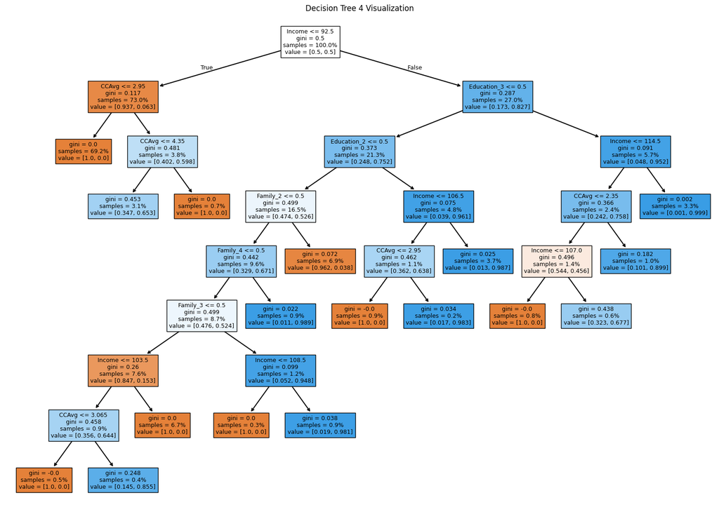

```python
# Feature names in X_train
feature_names = list(X_train.columns)

# Plotting the decision tree
plt.figure(figsize=(20, 14))
out = tree.plot_tree(dt4_model, feature_names=feature_names, filled=True, fontsize=9, node_ids=False, class_names=None, proportion=True)
plt.title("Decision Tree 4 Visualization")

# Adding arrows in the decision tree
for o in out:
  arrow = o.arrow_patch
  if arrow is not None:
    arrow.set_edgecolor('black')
    arrow.set_linewidth(1.5)
plt.show()
```

### **Observation**

**Increased Complexity**: The tree exhibits greater depth than the pre-pruned version.

**Key Influencing Factors**: To identify target candidates for the personal loan campaign, the model relied on Income, CCAvg, Education, and Family size as the primary predictors.

```python
# Print text report showing the decision tree 4 rules.
print(tree.export_text(dt4_model, feature_names=feature_names, show_weights=True))
```

```
|--- Income <= 92.50
|   |--- CCAvg <= 2.95
|   |   |--- weights: [1339.60, 0.00] class: 0
|   |--- CCAvg >  2.95
|   |   |--- CCAvg <= 4.35
|   |   |   |--- weights: [49.78, 93.75] class: 1
|   |   |--- CCAvg >  4.35
|   |   |   |--- weights: [13.27, 0.00] class: 0
|--- Income >  92.50
|   |--- Education_3 <= 0.50
|   |   |--- Education_2 <= 0.50
|   |   |   |--- Family_2 <= 0.50
|   |   |   |   |--- Family_4 <= 0.50
|   |   |   |   |   |--- Family_3 <= 0.50
|   |   |   |   |   |   |--- Income <= 103.50
|   |   |   |   |   |   |   |--- CCAvg <= 3.06
|   |   |   |   |   |   |   |   |--- weights: [9.96, 0.00] class: 0
|   |   |   |   |   |   |   |--- CCAvg >  3.06
|   |   |   |   |   |   |   |   |--- weights: [4.42, 26.04] class: 1
|   |   |   |   |   |   |--- Income >  103.50
|   |   |   |   |   |   |   |--- weights: [129.42, 0.00] class: 0
|   |   |   |   |   |--- Family_3 >  0.50
|   |   |   |   |   |   |--- Income <= 108.50
|   |   |   |   |   |   |   |--- weights: [4.98, 0.00] class: 0
|   |   |   |   |   |   |--- Income >  108.50
|   |   |   |   |   |   |   |--- weights: [2.77, 140.62] class: 1
|   |   |   |   |--- Family_4 >  0.50
|   |   |   |   |   |--- weights: [1.66, 145.83] class: 1
|   |   |   |--- Family_2 >  0.50
|   |   |   |   |--- weights: [133.30, 5.21] class: 0
|   |   |--- Education_2 >  0.50
|   |   |   |--- Income <= 106.50
|   |   |   |   |--- CCAvg <= 2.95
|   |   |   |   |   |--- weights: [17.15, 0.00] class: 0
|   |   |   |   |--- CCAvg >  2.95
|   |   |   |   |   |--- weights: [0.55, 31.25] class: 1
|   |   |   |--- Income >  106.50
|   |   |   |   |--- weights: [7.74, 598.96] class: 1
|   |--- Education_3 >  0.50
|   |   |--- Income <= 114.50
|   |   |   |--- CCAvg <= 2.35
|   |   |   |   |--- Income <= 107.00
|   |   |   |   |   |--- weights: [14.93, 0.00] class: 0
|   |   |   |   |--- Income >  107.00
|   |   |   |   |   |--- weights: [9.96, 20.83] class: 1
|   |   |   |--- CCAvg >  2.35
|   |   |   |   |--- weights: [9.96, 88.54] class: 1
|   |   |--- Income >  114.50
|   |   |   |--- weights: [0.55, 598.96] class: 1
```

### **Decision Tree (Closer Test & Train alphas)**

**Balancing Complexity and Performance**: The alpha parameter serves as a regulator, managing the trade-off between the tree's complexity and its predictive performance.

**Selecting the Optimal Alpha**: We select the alpha value that minimizes the difference between the testing and training performance metrics, identifying the point where the two align most closely.

**Improving Generalization**: Models derived from this optimal point (where the gap between train and test alpha is smallest) are expected to generalize more effectively to unseen data.

```python
# Compute the difference in recall between train and test and save in recall_diff
recall_diff = [abs(tr - te) for tr, te in zip(train_recall, test_recall)]

min_diff = min(recall_diff)
min_index = recall_diff.index(min_diff)

# Create the model where we get the highest test F1 score
dt5_model = clfs[min_index]

print(dt5_model)
```

```
DecisionTreeClassifier(ccp_alpha=np.float64(0.023074692478403356),
                       class_weight='balanced', random_state=1)
```

### **Observation**

- we clearly notice the alpha used is 0.023074692478403356, different from alpha used in post-pruned tree created from max alpha 0.00222
- This intersection point is also visible in "Recall vs Alpha for training and test data sets" graph

### **Model evaluation**

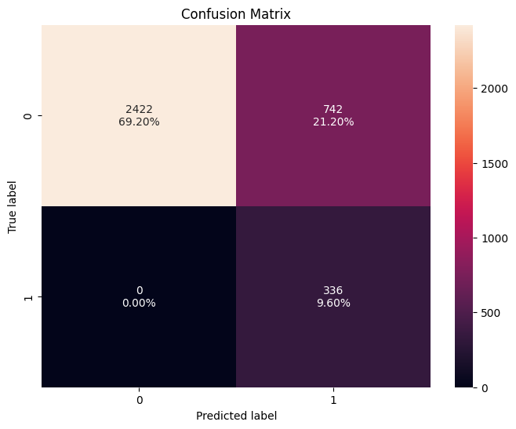

```python
# Plot confusion matrix with training data
confusion_matrix_sklearn(dt5_model, X_train, y_train)
```

```python
# Model performance classification metrics on training data set
dtree5_train_performance = model_performance_classification_sklearn(dt5_model, X_train, y_train)
dtree5_train_performance
```

|  | Metric | Score |
| --- | --- | --- |
| 0 | Accuracy | 0.788000 |
| 1 | Recall | 1.000000 |
| 2 | Precision | 0.311688 |
| 3 | F1 Score | 0.475248 |

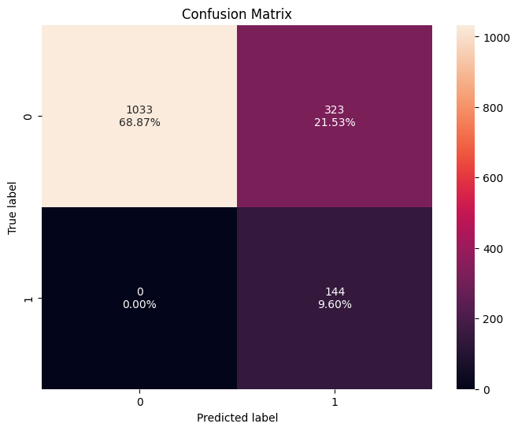

```python
# Plot confusion matrix with test data set
confusion_matrix_sklearn(dt5_model, X_test, y_test)
```

```python
# Model performance classification metrics on test data set
dtree5_test_performance = model_performance_classification_sklearn(dt5_model, X_test, y_test)
dtree5_test_performance
```

|  | Metric | Score |
| --- | --- | --- |
| 0 | Accuracy | 0.784667 |
| 1 | Recall | 1.000000 |
| 2 | Precision | 0.308351 |
| 3 | F1 Score | 0.471358 |

### **Model Performance Summary**

**Consistent Performance**: The results are similar to those achieved with the pre-pruning model.

**Perfect Recall (1.0)**: The model identifies all actual loan buyers, successfully supporting the bank's goal of capturing every potential customer.

**Low Precision (~31%)**: The high volume of false positives suggests that many non-buyers are incorrectly classified as potential customers.

**Balanced Trade-off**: With an accuracy of ~78% and an F1 score of ~0.47, the model is moderately effective, though it clearly prioritizes recall over precision.

### **Visualizing dtree5**

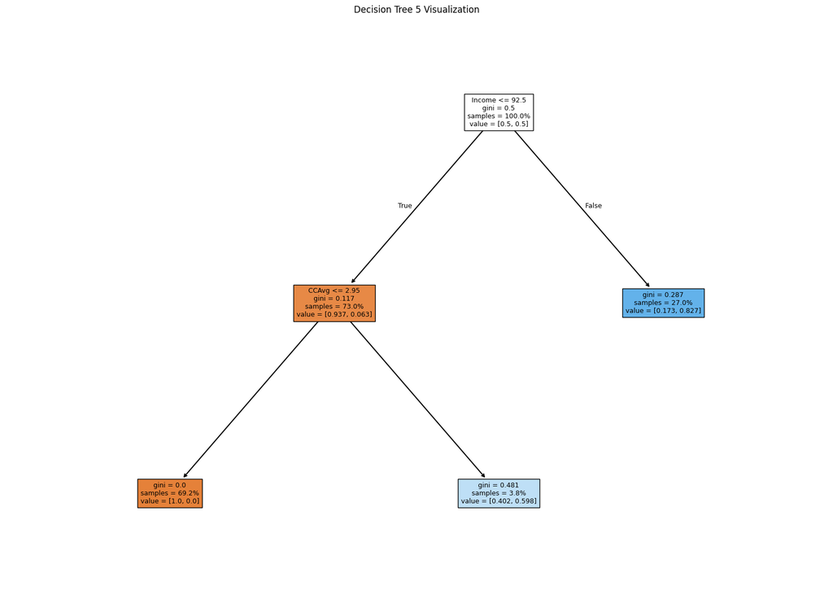

```python
# Feature names in X_train
feature_names = list(X_train.columns)

# Plotting the decision tree
plt.figure(figsize=(20, 14))
out = tree.plot_tree(dt5_model, feature_names=feature_names, filled=True, fontsize=9, node_ids=False, class_names=None, proportion=True)
plt.title("Decision Tree 5 Visualization")

# Adding arrows in the decision tree
for o in out:
  arrow = o.arrow_patch
  if arrow is not None:
    arrow.set_edgecolor('black')
    arrow.set_linewidth(1.5)
plt.show()
```

```python
# Print text report showing the decision tree 5 rules.
print(tree.export_text(dt5_model, feature_names=feature_names, show_weights=True))
```

```
|--- Income <= 92.50
|   |--- CCAvg <= 2.95
|   |   |--- weights: [1339.60, 0.00] class: 0
|   |--- CCAvg >  2.95
|   |   |--- weights: [63.05, 93.75] class: 1
|--- Income >  92.50
|   |--- weights: [347.35, 1656.25] class: 1
```

### **Model Comparison (Training dataset)**

```python
# Performance comparison on training

models_list = [
    dtree1_train_performance.set_index('Metric'),
    dtree2_train_performance.set_index('Metric'),
    dtree3_train_performance.set_index('Metric'),
    dtree4_train_performance.set_index('Metric'),
    dtree5_train_performance.set_index('Metric')
]

models_train_comparison_df = pd.concat(models_list, axis=1)

models_train_comparison_df.columns = [
    "DTree(sklearn default)",
    "DTree(default & balanced)",
    "DTree(Pre-Pruning)",
    "DTree(Post-Pruning, Max recall)",
    "DTree(Post-Pruning, Min Recall Diff)"
]
print("Performance comparison on training data")
models_train_comparison_df
```

```
Performance comparison on training data
```

| Metric | DTree(sklearn default) | DTree(default & balanced) | DTree(Pre-Pruning) | DTree(Post-Pruning, Max recall) | DTree(Post-Pruning, Min Recall Diff) |
| --- | --- | --- | --- | --- | --- |
| Accuracy | 1.0 | 1.0 | 0.788000 | 0.954571 | 0.788000 |
| Recall | 1.0 | 1.0 | 1.000000 | 0.997024 | 1.000000 |
| Precision | 1.0 | 1.0 | 0.311688 | 0.679513 | 0.311688 |
| F1 Score | 1.0 | 1.0 | 0.475248 | 0.808203 | 0.475248 |

### **Model Comparison (Test dataset)**

```python
# Performance comparison on training

models_list = [
    dtree1_test_performance.set_index('Metric'),
    dtree2_test_performance.set_index('Metric'),
    dtree3_test_performance.set_index('Metric'),
    dtree4_test_performance.set_index('Metric'),
    dtree5_test_performance.set_index('Metric')
]

models_test_comparison_df = pd.concat(models_list, axis=1)

models_test_comparison_df.columns = [
    "DTree(sklearn default)",
    "DTree(default & balanced)",
    "DTree(Pre-Pruning)",
    "DTree(Post-Pruning, Max recall)",
    "DTree(Post-Pruning, Min Recall Diff)"
]
print("Performance comparison on test data")
models_test_comparison_df
```

```
Performance comparison on test data
```

| Metric | DTree(sklearn default) | DTree(default & balanced) | DTree(Pre-Pruning) | DTree(Post-Pruning, Max recall) | DTree(Post-Pruning, Min Recall Diff) |
| --- | --- | --- | --- | --- | --- |
| Accuracy | 0.982667 | 0.978667 | 0.784667 | 0.953333 | 0.784667 |
| Recall | 0.937500 | 0.944444 | 1.000000 | 1.000000 | 1.000000 |
| Precision | 0.888158 | 0.850000 | 0.308351 | 0.672897 | 0.308351 |
| F1 Score | 0.912162 | 0.894737 | 0.471358 | 0.804469 | 0.471358 |

### **Final Model Selection**

**1. Standard Decision Tree (Default)** - Suffers from severe overfitting. While it achieves perfect scores (1.0) on training data, precision on the test set declines to ~89%.

**3. Pre-Pruning Decision Tree** - Achieves 100% recall but suffers from very low precision (~31%). While it successfully identifies all potential customers, the high volume of false positives leads to poor targeting efficiency and risks annoying non-interested customers.

**4. Post-Pruning Decision Tree (Max Recall)** - Provides an excellent balance, maintaining 1.0 recall alongside ~67% precision and an F1 score of ~0.80 on both datasets.

This model offers the best generalization and cost-effectiveness, making it the most suitable candidate for real-world marketing deployment.

**5. Post-Pruning Decision Tree (Minimal Recall Difference)** - Mirrors the pre-pruning results; while recall is perfect, the precision and F1 scores remain suboptimal.

Similar to the pre-pruning approach, the lack of precision significantly hampers the efficiency of targeted campaigns.

## **Model Recommendation:**

The Post-Pruning model optimized for Max Recall is the preferred choice. It effectively balances the need to capture all potential responders while minimizing false positives, ensuring a focused and high-impact marketing strategy.

### **Feature importance for final model**

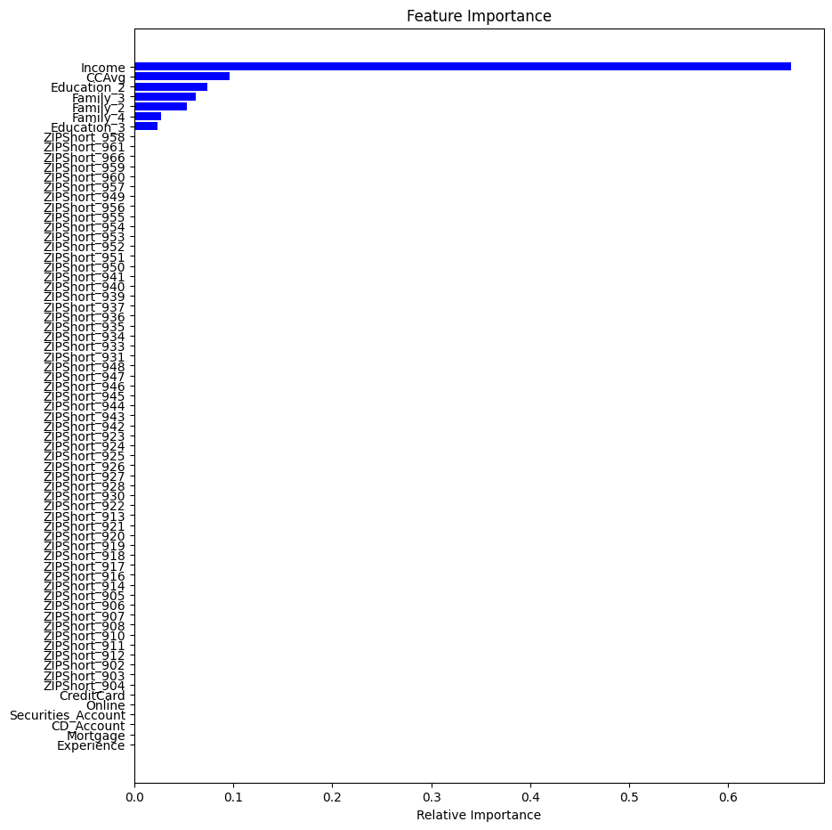

```python
# Importance of features in the tree

importances = dt4_model.feature_importances_
indices = np.argsort(importances)

plt.figure(figsize=(10, 11))
plt.title("Feature Importance")
plt.barh(range(len(indices)), importances[indices], color='b', align='center')
plt.yticks(range(len(indices)), [feature_names[i] for i in indices])
plt.xlabel("Relative Importance")
plt.show()
```

### **Single data point prediction**

```python
%%time
# Choose data point
customer_data = X_test.iloc[19:20, :]

# Prediction Making
asset_customer_prediction = dt4_model.predict(customer_data)
print(asset_customer_prediction)
```

```
[1]
CPU times: user 2.69 ms, sys: 0 ns, total: 2.69 ms
Wall time: 2.65 ms
```

- Our final model is able to do the prediction around 2-3 milliseconds.
- Model is predicting the likelihood of customer taking a personal load from the marketing campaign

```python
# Prediction Making
asset_customer_prediction_proba = dt4_model.predict_proba(customer_data)
print(asset_customer_prediction_proba[0,1])
```

```
0.9990774198508495
```

Our recommended final model predicted the customers likelihood to avail a personal load as near 1.

# **Actionable Insights & Recommendations**

## **Business Recommendations**

1. **Prioritize High-Income Segments**: Income is your strongest predictor; target customers earning >$92.5k, as they are most likely to accept personal loan offers.
2. **Use Spending Patterns as a Filter**: Utilize average credit card spending (CCAvg >$2.95k) as a secondary filter to refine and sharpen your target lists.
3. **Personalize via Demographics**: Tailor marketing messages based on education levels (graduates and professionals) and family size to improve engagement.
4. **Optimize Marketing Spend**: Precision is ~67%; avoid "blanket" campaigns. Instead, use model scores to tier customers and focus outreach on those most likely to convert to prevent wasted budget and customer fatigue.
5. **Drive Upsell Strategies**: Specifically target deposit-only customers who demonstrate high income and active credit card usage with pre-approved loan offers or preferential interest rates.